# Vector Meson Production

This file contains the entirety of the vector meson production functions and results for the CGC, b-CGC, and b-SAT models. It is written to be run on a Windows machine, but can easily be edited for a Linux-type machine. The only changes that must be made are in the b-SAT imaginary scattering amplitude functions (change `shell()` to `system()`), and the encoding in the `pdf()` calls when creating plots (add `encoding = “Greek”` to the arguments so sigma will display properly).

## References and Libraries

```r
# William Woodley (wwoodley@ualberta.ca)
# 3 August 2018

# References

# [1]: M. Ahmady, R. Sandapen, and N. Sharma, Phys. Rev. D 94, 074018 (2016), arXiv:1605.07665v2 [hep-ph].
# [2]: A. H. Rezaeian, and I. Schmidt, Phys. Rev. D 88, 074016 (2013), arXiv:1307.0825v3 [hep-ph].
# [3]: A. H. Rezaeian, et al., Phys. Rev. D 87, 034002 (2013), arXiv:1212.2974v1 [hep-ph].
# [4]: G. Watt, and H. Kowalski, Phys. Rev. D 78, 014016 (2008), arXiv:0712.2670v2 [hep-ph].
# [5]: S. A. Tehrani, and A. N. Khorramian, J. High Energy Phys. 0707:048 (2007), arXiv:0705.2647v2 [hep-ph].
# [6]: S. Bethke, G. Dissertori, and G. P. Salam, Quantum Chromodynamics (2015), PDG.

# References for experimental data

# [7]:  C. Adloff et al. (H1 Collaboration), Eur. Phys. J. C 13, 371 (2000).
# [8]:  F. D. Aaron et al. (H1 Collaboration), J. High Energy Phys. 05 (2010) 032.
# [9]:  S. Chekanov et al. (ZEUS Collaboration), Nucl. Phys. B718, 3 (2005), arXiv:hep-ex/0504010.
# [10]: S. Chekanov et al. (ZEUS Collaboration), PMC Phys. A 1, 6 (2007).

# Libraries

library(cubature)     # For adaptIntegrate()
library(memoise)      # To cache variables using the memoise() function to make repeated calculations faster
library(compiler)     # To compile functions using cmpfun() to make them faster
library(tidyverse)    # To manipulate dataframes in the VMP() wrapper functions
library(readxl)       # To import experimental data from excel spreadsheets
```

## Constants and Parameters

```r
# Define Bessel functions for shorthand

K = function (input) { besselK(input, 0) }
J = function (input) { besselJ(input, 0) }

# Constants

q_e        = sqrt(4*pi*(1/137)) # The elementary charge
kappa      = 0.54               # The mass scale
Lambda_QCD = 0.156              # For the coupling constant
N_c        = 3                  # The number of colours
n_f        = 4                  # The number of active flavours

# Equations (9.3) from Reference [6]

b_0 = (33 - 2*n_f)/(12*pi)                                  # The one-loop beta function coefficient
b_1 = (153 - 19*n_f)/(24*(pi**2))                           # The two-loop beta function coefficient
b_2 = (2857 - (5033/9)*n_f + (325/27)*n_f**2)/(128*(pi**3)) # The three-loop beta function coefficient

# CGC model parameters from Reference [1], Table 4

#                  gamma_s lambda x_nought N_nought sigma_nought (in nanobarns)
CGC_parameters = c(0.724,  0.206, 6.33e-6, 0.7,     29.9/0.389379)

CGC_gamma_s      = CGC_parameters[1]
CGC_lambda       = CGC_parameters[2]
CGC_x_nought     = CGC_parameters[3]
CGC_N_nought     = CGC_parameters[4]
CGC_sigma_nought = CGC_parameters[5]

# b-CGC model parameters from Reference [2], Table 2

#                   gamma_s lambda  x_nought N_nought B_CGC
bCGC_parameters = c(0.6599, 0.2063, 0.00105, 0.3358,  5.5)

bCGC_gamma_s  = bCGC_parameters[1]
bCGC_lambda   = bCGC_parameters[2]
bCGC_x_nought = bCGC_parameters[3]
bCGC_N_nought = bCGC_parameters[4]
bCGC_B_CGC    = bCGC_parameters[5]

# b-SAT model parameters from Reference [3], Table 1

#                   A_g    lambda_g mu_nought   B_G C
bSAT_parameters = c(2.308, 0.058,   sqrt(1.51), 4,  4)

A_g       = bSAT_parameters[1]
lambda_g  = bSAT_parameters[2]
mu_nought = bSAT_parameters[3]
B_G       = bSAT_parameters[4]
bSAT_C    = bSAT_parameters[5]
```

## Normalisation Constants

The normalisation constants are calculated from the vector meson wavefunctions only:

$$\mathcal{N}_{\lambda}=\frac{1}{2\pi\displaystyle\sum_{h,\ \bar{h}}\int_0^1\int_0^{\infty}r\left|\Psi_{h,\ \bar{h}}^{V,\ \lambda}(x,\ r)\right|^2\mathrm{d}r\mathrm{d}x}$$

The factor of $2\pi r$ comes from integrating $\mathrm{d}^2\mathbf{r}=r\mathrm{d}r\mathrm{d}\theta$ over $\theta$ from 0 to $2\pi$.

The normalisation constants are, therefore, independent of the dipole model, and so the same `N_L` and `N_T` can be used in the CGC, b-CGC, and b-SAT calculations.

```r
# Longitudinal normalisation constant function

Normalise_L = function (variables, meson) {

  # Integration variables

  x = variables[1]
  r = variables[2]

  # Set the meson-dependent constant values

  if (meson == "rho") {

    M = 0.776
    m = 0.14

  } else if (meson == "phi") {

    M = 1.020
    m = 0.14

  }

  # Wavefunctions from Equations (14) and (27) from Reference [1], simplified by hand

  exponent = exp((-1/2)*(((kappa**2)*(r**2)*x*(1 - x)) + ((m**2)/((kappa**2)*x*(1 - x)))))

  psi = sqrt(x*(1 - x))*exponent
  psi_dr2 = (kappa**2)*((x*(1 - x))**(3/2))*((kappa**2)*(r**2)*x*(1 - x) - 2)*exponent

  # Return the N_L integrand

  (1/2)*pi*r*((psi**2) + (2*(m**2)*(psi**2) - 2*psi*psi_dr2)/(x*(1 - x)*(M**2)) + ((m**4)*(psi**2) + (psi_dr2**2) - (2*(m**2)*psi*psi_dr2))/((x*(1 - x)*(M**2))**2))

}

# Transverse normalisation constant function

Normalise_T = function (variables, meson) {

  # Integration variables

  x = variables[1]
  r = variables[2]

  # Set the meson-dependent constant values

  if (meson == "rho") {

    m = 0.14

  } else if (meson == "phi") {

    m = 0.14

  }

  # Wavefunctions from Equations (14) and (27) from Reference [1], simplified by hand

  exponent = exp((-1/2)*(((kappa**2)*x*(1 - x)*(r**2)) + ((m**2)/((kappa**2)*x*(1 - x)))))

  psi = sqrt(x*(1 - x))*exponent
  psi_dr = -((x*(1 - x))**(3/2))*(kappa**2)*r*exponent

  # Return the N_T integrand

  2*pi*r*(1/(4*(x**2)*((1 - x)**2)))*(((x**2 + (1 - x)**2)*(psi_dr**2)) + (m*psi)**2)

}
```

Because `adaptIntegrate()` cannot integrate to infinity, an upper limit for `r` on the integrals used to calculate `N_L` and `N_T` must be chosen. Therefore, plot the functions to see where they go to zero.

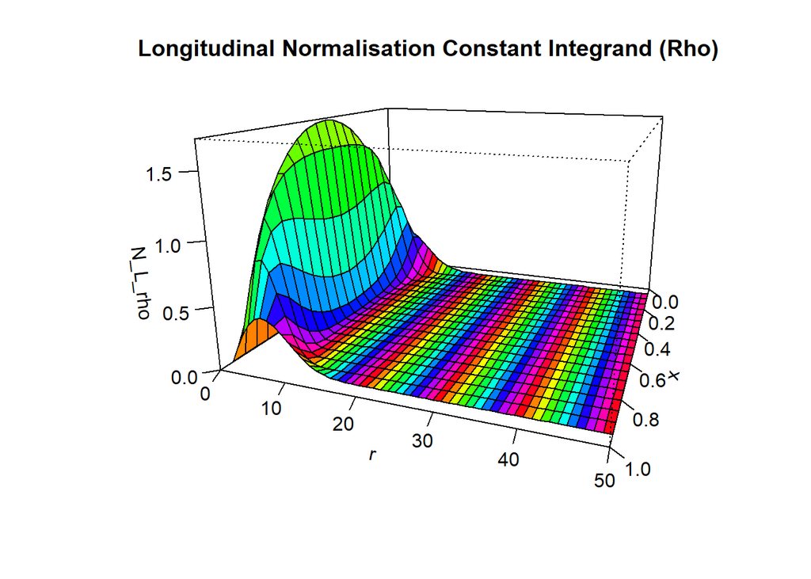

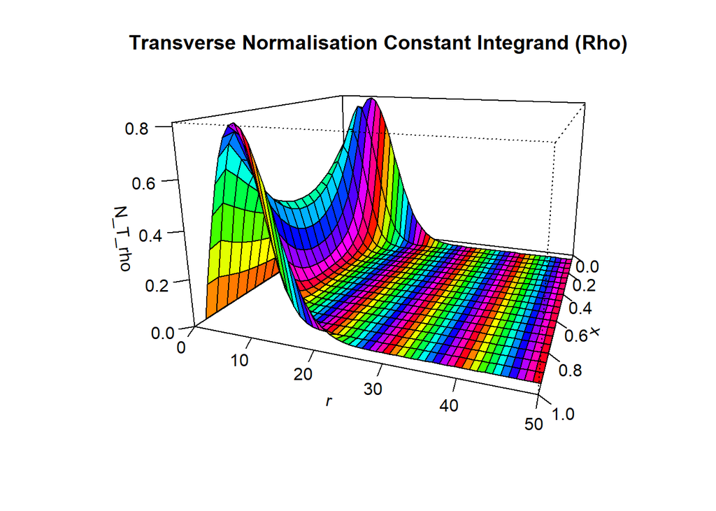

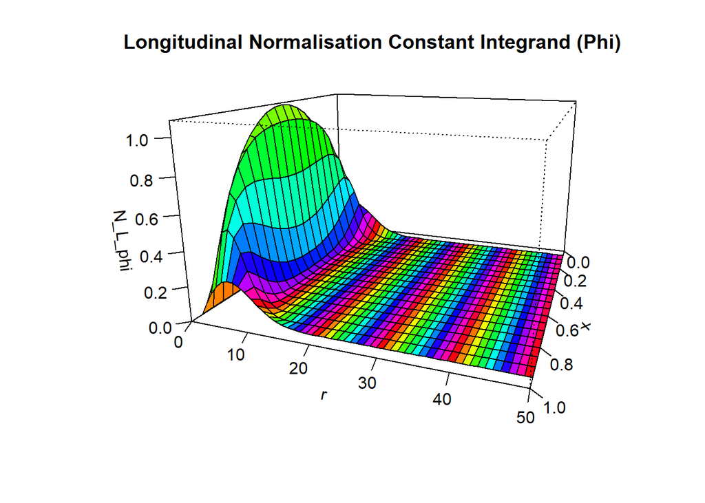

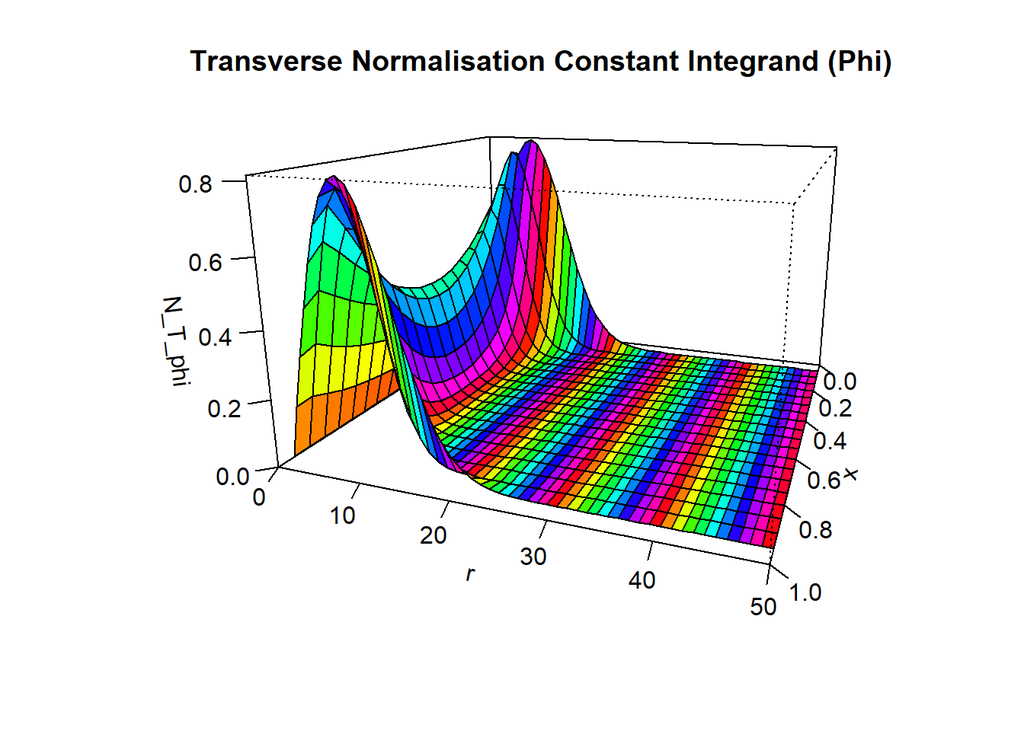

```r
# Redefine the Normalisat_L and Normalise_T functions to take x and r in as separate variables

Normalise_L_plot = Vectorize(function (x, r, meson) { Normalise_L(c(x, r), meson) })
Normalise_T_plot = Vectorize(function (x, r, meson) { Normalise_T(c(x, r), meson) })

x_seq = seq(from = 0, to = 1, by = 0.05)
r_seq = seq(from = 0, to = 50, by = 1)

values_L_rho = outer(x_seq, r_seq, Normalise_L_plot, meson = "rho")
values_T_rho = outer(x_seq, r_seq, Normalise_T_plot, meson = "rho")

persp(x_seq, r_seq, values_L_rho, xlab = "x", ylab = "r", zlab = "N_L_rho", main = "Longitudinal Normalisation Constant Integrand (Rho)", theta = 110, expand = 0.6, col = rainbow(200), ticktype = "detailed")
persp(x_seq, r_seq, values_T_rho, xlab = "x", ylab = "r", zlab = "N_T_rho", main = "Transverse Normalisation Constant Integrand (Rho)", theta = 110, expand = 0.6, col = rainbow(200), ticktype = "detailed")

values_L_phi = outer(x_seq, r_seq, Normalise_L_plot, meson = "phi")
values_T_phi = outer(x_seq, r_seq, Normalise_T_plot, meson = "phi")

persp(x_seq, r_seq, values_L_phi, xlab = "x", ylab = "r", zlab = "N_L_phi", main = "Longitudinal Normalisation Constant Integrand (Phi)", theta = 110, expand = 0.6, col = rainbow(200), ticktype = "detailed")
persp(x_seq, r_seq, values_T_phi, xlab = "x", ylab = "r", zlab = "N_T_phi", main = "Transverse Normalisation Constant Integrand (Phi)", theta = 110, expand = 0.6, col = rainbow(200), ticktype = "detailed")
```

The plots are symmetric in `x`, as expected. From these plots, the upper limit for `r` can be set to 25 for `N_L`, and to 100 for `N_T`.

```r
# Normalisation constants for rho

N_L_rho = 1/sqrt(adaptIntegrate(Normalise_L, lowerLimit = c(0, 0), upperLimit = c(1, 25), meson = "rho")$integral)
N_T_rho = 1/sqrt(adaptIntegrate(Normalise_T, lowerLimit = c(0, 0), upperLimit = c(1, 100), meson = "rho")$integral)

# Normalisation constants for phi

N_L_phi = 1/sqrt(adaptIntegrate(Normalise_L, lowerLimit = c(0, 0), upperLimit = c(1, 25), meson = "phi")$integral)
N_T_phi = 1/sqrt(adaptIntegrate(Normalise_T, lowerLimit = c(0, 0), upperLimit = c(1, 100), meson = "phi")$integral)

cat("Rho:\n")
cat("N_L =", N_L_rho, "\n")
cat("N_T =", N_T_rho, "\n\n")

cat("Phi:\n")
cat("N_L =", N_L_phi, "\n")
cat("N_T =", N_T_phi)
```

```
## Rho:
## N_L = 0.4463203
## N_T = 0.5182588
##
## Phi:
## N_L = 0.5502141
## N_T = 0.5182588
```

# 1. The CGC Model

## The Imaginary Scattering Amplitudes

```r
# Longitudinal imaginary scattering amplitude function

CGC_A_L = function (variables, x_Bj, Q2, meson) {

  # Integration variables

  x = variables[1]
  r = variables[2]

  # Set the meson-dependent constant values

  if (meson == "rho") {

    M = 0.776
    m = 0.14
    e = 0.707107

    N_L = N_L_rho

  } else if (meson == "phi") {

    M = 1.020
    m = 0.14
    e = 0.333333

    N_L = N_L_phi

  }

  # Parameter- and variable-dependent equations

  A       = -(CGC_N_nought*CGC_gamma_s)**2/((1 - CGC_N_nought)**2*log(1 - CGC_N_nought)) # Equation (39) from Reference [1]
  B       = (1/2)*(1 - CGC_N_nought)**((CGC_N_nought - 1)/(CGC_N_nought*CGC_gamma_s))    # Equation (39) from Reference [1]
  Q_s     = ((CGC_x_nought/x_Bj)**(CGC_lambda/2))                                        # Equation (38) from Reference [1]
  epsilon = sqrt(x*(1 - x)*Q2 + m**2)                                                    # Equation (8)  from Reference [1]

  # Equation (38) from Reference [1]

  N = ifelse(r*Q_s > 2,
             1 - exp(-A*((log(B*r*Q_s))**2)),
             CGC_N_nought*(r*Q_s/2)**(2*(CGC_gamma_s + (log(2/(r*Q_s)))/(9.9*CGC_lambda*log(1/x_Bj)))))

  # Wavefunctions from Equations (14) and (27) from Reference [1], simplified by hand

  exponent = exp((-1/2)*((kappa**2)*x*(1 - x)*r**2 + (m**2)/((kappa**2)*x*(1 - x))))

  psi     = sqrt(x*(1 - x))*exponent
  psi_dr2 = ((x*(1 - x))**(3/2))*(kappa**2)*((r**2)*(kappa**2)*x*(1 - x) - 2)*exponent

  # The photon and the vector meson wavefunctions

  psi_p = sqrt(N_c/pi)*q_e*e*x*(1 - x)*sqrt(Q2)*(K(epsilon*r)/pi)
  psi_V = (N_L/(2*sqrt(2)))*((1 + ((m**2)/(x*(1 - x)*(M**2))))*psi - (1/(x*(1 - x)*(M**2)))*psi_dr2)

  # Return the integrand for the longitudinal scattering amplitude

  2 *                       # Integrate x from 0 to 0.5
  psi_p *                   # The photon wavefunction
  psi_V *                   # The complex conjugate of the vector meson wavefunction
  2*pi*r*CGC_sigma_nought*N # The dipole cross section

}

# Transverse imaginary scattering amplitude function

CGC_A_T = function (variables, x_Bj, Q2, meson) {

  # Integration variables

  x = variables[1]
  r = variables[2]

  # Set the meson-dependent constant values

  if (meson == "rho") {

    M = 0.776
    m = 0.14
    e = 0.707107

    N_T = N_T_rho

  } else if (meson == "phi") {

    M = 1.020
    m = 0.14
    e = 0.333333

    N_T = N_T_phi

  }

  # Parameter- and variable-dependent equations

  A       = -(CGC_N_nought*CGC_gamma_s)**2/((1 - CGC_N_nought)**2*log(1 - CGC_N_nought)) # Equation (39) from Reference [1]
  B       = (1/2)*(1 - CGC_N_nought)**((CGC_N_nought - 1)/(CGC_N_nought*CGC_gamma_s))    # Equation (39) from Reference [1]
  Q_s     = ((CGC_x_nought/x_Bj)**(CGC_lambda/2))                                        # Equation (38) from Reference [1]
  epsilon = sqrt(x*(1 - x)*Q2 + m**2)                                                    # Equation (8)  from Reference [1]

  # Equation (38) from Reference [1]

  N = ifelse(r*Q_s > 2,
             1 - exp(-A*((log(B*r*Q_s))**2)),
             CGC_N_nought*(r*Q_s/2)**(2*(CGC_gamma_s + (log(2/(r*Q_s)))/(9.9*CGC_lambda*log(1/x_Bj)))))

  # Wavefunctions from Equations (14) and (27) from Reference [1], simplified by hand

  exponent = exp((-1/2)*((kappa**2)*x*(1 - x)*r**2 + (m**2)/((kappa**2)*x*(1 - x))))

  psi = sqrt(x*(1 - x))*exponent
  psi_dr = -((x*(1 - x))**(3/2))*(kappa**2)*r*exponent

  # Product of the photon wavefunction and the complex conjugate of the vector meson wavefunction

  psi_Vp = N_T*sqrt(N_c/(2*pi))*q_e*e*((x**2 + (1 - x)**2)*(-epsilon*(besselK(epsilon*r, 1))/(2*pi))*(psi_dr/(2*x*(1 - x))) + (m**2)*(K(epsilon*r)/(2*pi))*(psi/(2*x*(1 - x))))

  # Return the integrand for the transverse scattering amplitude

  2 *                       # Integrate x from 0 to 0.5
  psi_Vp *                  # The wavefunctions
  2*pi*r*CGC_sigma_nought*N # The dipole cross section

}

CGC_A_L = memoise(cmpfun(CGC_A_L))
CGC_A_T = memoise(cmpfun(CGC_A_T))
```

### Test Values

```r
# x_Bj = 0.008916683 corresponds to W = 75

cat("Rho:\n")
CGC_A_L(variables = c(0.5, 10), x_Bj = 0.008916683, Q2 = 50, meson = "rho")
CGC_A_T(variables = c(0.5, 10), x_Bj = 0.008916683, Q2 = 50, meson = "rho")

# x_Bj = 0.006262625 corresponds to W = 90

cat("\nPhi:\n")
CGC_A_L(variables = c(0.5, 10), x_Bj = 0.006262625, Q2 = 50, meson = "phi")
CGC_A_T(variables = c(0.5, 10), x_Bj = 0.006262625, Q2 = 50, meson = "phi")
```

```
## Rho:
## [1] -2.637773e-16
## [1] 3.213441e-16
##
## Phi:
## [1] -4.364689e-17
## [1] 1.515847e-16
```

## The Differential Cross Section, Total Cross Section, and Ratio

```r
# Longitudinal differential cross section and cross section function

CGC_sigma_L = function (x_Bj, Q2, t, meson) {

  # Set the meson-dependent constant values

  if (meson == "rho") {

    M = 0.776

  } else if (meson == "phi") {

    M = 1.020

  }

  # Real-part correction

  ImA_L_x = adaptIntegrate(CGC_A_L, lowerLimit = c(1e-10, 1e-10), upperLimit = c(0.5, 100), x_Bj, Q2, meson, tol = 1e-2)$integral
  ImA_L_h = adaptIntegrate(CGC_A_L, lowerLimit = c(1e-10, 1e-10), upperLimit = c(0.5, 100), x_Bj + 1e-15, Q2, meson, tol = 1e-2)$integral

  # Limit definition of the derivative of x_Bj

  alpha = -x_Bj*(1/(1e-15))*log(abs(ImA_L_x/ImA_L_h)) # Alternative form of Equation (13) from Reference [1]
  beta  = tan(pi*alpha/2)                             # Equation (13) from Reference [1]

  multiplier =
  (ImA_L_x**2) *              # Im(A_L) squared
  (1/(16*pi))*(1 + beta**2) * # Real-part correction
  3.89379e5                   # Convert to nanobarns

  # Equation (11) from Reference [1]

  B_D = 0.55*(14*((1/(Q2 + (M**2)))**0.2) + 1)

  d_sigma_L = multiplier * exp(-B_D*t)
  sigma_L   = multiplier * (1/B_D)

  # Return a vector of the differential cross section and the cross section

  c(d_sigma_L, sigma_L)

}

# Transverse differential cross section and cross section function

CGC_sigma_T = function (x_Bj, Q2, t, meson) {

  # Set the meson-dependent constant values

  if (meson == "rho") {

    M = 0.776

  } else if (meson == "phi") {

    M = 1.020

  }

  # Real-part correction

  ImA_T_x = adaptIntegrate(CGC_A_T, lowerLimit = c(1e-10, 1e-10), upperLimit = c(0.5, 100), x_Bj, Q2, meson, tol = 1e-2)$integral
  ImA_T_h = adaptIntegrate(CGC_A_T, lowerLimit = c(1e-10, 1e-10), upperLimit = c(0.5, 100), x_Bj + 1e-15, Q2, meson, tol = 1e-2)$integral

  # Limit definition of the derivative of x_Bj

  alpha = -x_Bj*(1/(1e-15))*log(abs(ImA_T_x/ImA_T_h)) # Alternative form of Equation (13) from Reference [1]
  beta  = tan(pi*alpha/2)                             # Equation (13) from Reference [1]

  multiplier =
  (ImA_T_x**2) *              # Im(A_L) squared
  (1/(16*pi))*(1 + beta**2) * # Real-part correction
  3.89379e5                   # Convert to nanobarns

  # Equation (11) from Reference [1]

  B_D = 0.55*(14*((1/(Q2 + (M**2)))**0.2) + 1)

  d_sigma_T = multiplier * exp(-B_D*t)
  sigma_T   = multiplier * (1/B_D)

  # Return a vector of the differential cross section and the cross section

  c(d_sigma_T, sigma_T)

}

CGC_sigma_L = memoise(Vectorize(cmpfun(CGC_sigma_L)))
CGC_sigma_T = memoise(Vectorize(cmpfun(CGC_sigma_T)))
```

### Test Values

```r
# x_Bj = 0.008916683 corresponds to W = 75

cat("Rho:\n")
CGC_sigma_L(x_Bj = 0.008916683, Q2 = 50, t = 0.5, meson = "rho")
CGC_sigma_T(x_Bj = 0.008916683, Q2 = 50, t = 0.5, meson = "rho")

# x_Bj = 0.006262625 corresponds to W = 90

cat("\nPhi:\n")
CGC_sigma_L(x_Bj = 0.006262625, Q2 = 50, t = 0.5, meson = "phi")
CGC_sigma_T(x_Bj = 0.006262625, Q2 = 50, t = 0.5, meson = "phi")

# The output (for three Q^2 values) is of the form:

#      [,1]      [,2]      [,3]
# [1,] d_sigma_1 d_sigma_2 d_sigma_3
# [2,] sigma_1   sigma_2   sigma_3
```

```
## Rho:
##           [,1]
## [1,] 0.1825868
## [2,] 0.3426675
##            [,1]
## [1,] 0.02286339
## [2,] 0.04290858
##
## Phi:
##            [,1]
## [1,] 0.04360691
## [2,] 0.08171313
##             [,1]
## [1,] 0.005919397
## [2,] 0.011092107
```

## The CGC Data Frame Wrapper

```r
# Cross section and ratio function

CGC_VMP = function (x_Bj, Q2, t, meson) {

  sigma_L = CGC_sigma_L(x_Bj, Q2, t, meson)
  sigma_T = CGC_sigma_T(x_Bj, Q2, t, meson)

  d_sigma = sigma_T[1] + 0.98*sigma_L[1]
  sigma   = sigma_T[2] + 0.98*sigma_L[2]
  ratio   = sigma_L[2]/sigma_T[2]

  c(d_sigma, sigma, ratio)

}

CGC_VMP = memoise(Vectorize(cmpfun(CGC_VMP)))

# A wrapper in order to return the results in a data frame
# Calculate x_Bj inside this function in order to display it in the data frame

CGC = function(Q2, W, t = 0, meson) {

  # Set the meson-dependent constant values

  if (meson == "rho") {

    M = 0.776

  } else if (meson == "phi") {

    M = 1.020

  } else {

    stop("Not a valid meson")

  }

  # Modified x_Bj for low Q2

  x_Bj = (Q2 + (M**2))/(Q2 + (W**2))

  output = as.data.frame(t(CGC_VMP(x_Bj, Q2, t, meson)))
  output = mutate(output, x_Bj, W, Q2, t)
  rownames(output) = NULL
  colnames(output) = c("d_sigma", "sigma", "ratio", "x_Bj", "W", "Q2", "t")
  output = select(output, Q2, W, x_Bj, t, d_sigma, sigma, ratio)
  output

}

CGC = memoise(cmpfun(CGC))
```

### Test Values

```r
CGC(Q2 = 50, W = 75, t = 0.5, meson = "rho")
```

| Q2 | W | x_Bj | t | d_sigma | sigma | ratio |
| --- | --- | --- | --- | --- | --- | --- |
| 50 | 75 | 0.008916683 | 0.5 | 0.2012411 | 0.3776766 | 7.961112 |

```r
CGC(Q2 = 50, W = 90, t = 0.5, meson = "phi")
```

| Q2 | W | x_Bj | t | d_sigma | sigma | ratio |
| --- | --- | --- | --- | --- | --- | --- |
| 50 | 90 | 0.006262626 | 0.5 | 0.04847209 | 0.09082979 | 7.348214 |

# 2. The b-CGC Model

## The Imaginary Scattering Amplitudes

```r
# Longitudinal imaginary scattering amplitude function

bCGC_A_L = function (variables, x_Bj, Q2, t, meson) {

  # Integration variables

  b = variables[1]
  x = variables[2]
  r = variables[3]

  # Set the meson-dependent constant values

  if (meson == "rho") {

    M = 0.776
    m = 0.14
    e = 0.707107

    N_L = N_L_rho

  } else if (meson == "phi") {

    M = 1.020
    m = 0.14
    e = 0.333333

    N_L = N_L_phi

  }

  # Parameter- and variable-dependent equations

  A       = -((bCGC_N_nought*bCGC_gamma_s)**2)/(((1 - bCGC_N_nought)**2)*log(1 - bCGC_N_nought))          # Equation (39) from Reference [1]
  B       = (1/2)*(1 - bCGC_N_nought)**((bCGC_N_nought - 1)/(bCGC_N_nought*bCGC_gamma_s))                 # Equation (39) from Reference [1]
  Q_s     = ((bCGC_x_nought/x_Bj)**(bCGC_lambda/2))*((exp(-(b**2)/(2*bCGC_B_CGC)))**(1/(2*bCGC_gamma_s))) # Equation (9)  from Reference [4]
  epsilon = sqrt(x*(1 - x)*Q2 + m**2)                                                                     # Equation (8)  from [1]

  # Equation (8) from Reference [4]

  N = ifelse(r*Q_s > 2,
             1 - exp(-A*(log(B*r*Q_s))**2),
             bCGC_N_nought*(r*Q_s/2)**(2*(bCGC_gamma_s + (log(2/(r*Q_s)))/(9.9*bCGC_lambda*log(1/x_Bj)))))

  # Wavefunctions from Equations (14) and (27) from Reference [1], simplified by hand

  exponent = exp((-1/2)*((kappa**2)*x*(1 - x)*r**2 + (m**2)/((kappa**2)*x*(1 - x))))

  psi     = sqrt(x*(1 - x))*exponent
  psi_dr2 = ((x*(1 - x))**(3/2))*(kappa**2)*((r**2)*(kappa**2)*x*(1 - x) - 2)*exponent

  # The photon and the vector meson wavefunctions

  psi_p = sqrt(N_c/pi)*q_e*e*x*(1 - x)*sqrt(Q2)*(K(epsilon*r)/pi)
  psi_V = (N_L/(2*sqrt(2)))*((1 + ((m**2)/(x*(1 - x)*(M**2))))*psi - (1/(x*(1 - x)*(M**2)))*psi_dr2)

  # Return the integrand for the longitudinal scattering amplitude

  2 *                     # Integrate x from 0 to 0.5
  psi_p *                 # The photon wavefunction
  psi_V *                 # The complex conjugate of the vector meson wavefunction
  2*N *                   # The dipole cross section
  2*pi*r*J(x*r*sqrt(t)) * # The r Bessel function
  2*pi*b*J(b*sqrt(t))     # The b Bessel function

}

# Transverse imaginary scattering amplitude function

bCGC_A_T = function (variables, x_Bj, Q2, t, meson) {

  # Integration variables

  b = variables[1]
  x = variables[2]
  r = variables[3]

  # Set the meson-dependent constant values

  if (meson == "rho") {

    M = 0.776
    m = 0.14
    e = 0.707107

    N_T = N_T_rho

  } else if (meson == "phi") {

    M = 1.020
    m = 0.14
    e = 0.333333

    N_T = N_T_phi

  }

  # Parameter- and variable-dependent equations

  A       = -((bCGC_N_nought*bCGC_gamma_s)**2)/(((1 - bCGC_N_nought)**2)*log(1 - bCGC_N_nought))          # Equation (39) from Reference [1]
  B       = (1/2)*(1 - bCGC_N_nought)**((bCGC_N_nought - 1)/(bCGC_N_nought*bCGC_gamma_s))                 # Equation (39) from Reference [1]
  Q_s     = ((bCGC_x_nought/x_Bj)**(bCGC_lambda/2))*((exp(-(b**2)/(2*bCGC_B_CGC)))**(1/(2*bCGC_gamma_s))) # Equation (9)  from Reference [4]
  epsilon = sqrt(x*(1 - x)*Q2 + m**2)                                                                     # Equation (8)  from [1]

  # Equation (8) from Reference [4]

  N = ifelse(r*Q_s > 2,
             1 - exp(-A*(log(B*r*Q_s))**2),
             bCGC_N_nought*(r*Q_s/2)**(2*(bCGC_gamma_s + (log(2/(r*Q_s)))/(9.9*bCGC_lambda*log(1/x_Bj)))))

  # Wavefunctions from Equations (14) and (27) from Reference [1], simplified by hand

  exponent = exp((-1/2)*(((kappa**2)*x*(1 - x)*(r**2)) + ((m**2)/((kappa**2)*x*(1 - x)))))

  psi = sqrt(x*(1 - x))*exponent
  psi_dr = -((x*(1 - x))**(3/2))*(kappa**2)*r*exponent

  # Product of the photon wavefunction and the complex conjugate of the vector meson wavefunction

  psi_Vp = N_T*sqrt(N_c/(2*pi))*q_e*e*((x**2 + (1 - x)**2)*(-epsilon*(besselK(epsilon*r, 1))/(2*pi))*(psi_dr/(2*x*(1 - x))) + (m**2)*(K(epsilon*r)/(2*pi))*(psi/(2*x*(1 - x))))

  # Return the integrand for the longitudinal scattering amplitude

  2 *                     # Integrate x from 0 to 0.5
  psi_Vp *                # The wavefunctions
  2*N *                   # The dipole cross section
  2*pi*r*J(x*r*sqrt(t)) * # The r Bessel function
  2*pi*b*J(b*sqrt(t))     # The b Bessel function

}

bCGC_A_L = memoise(cmpfun(bCGC_A_L))
bCGC_A_T = memoise(cmpfun(bCGC_A_T))

# Longitudinal imaginary scattering amplitude integration function

bCGC_IntA_L = function (x_Bj, Q2, t, meson) {

  adaptIntegrate(bCGC_A_L, lowerLimit = c(1e-15, 1e-15, 1e-15), upperLimit = c(5, 0.5, 20), x_Bj, Q2, t, meson, tol = 0.01)$integral

}

# Transverse imaginary scattering amplitude integration function

bCGC_IntA_T = function (x_Bj, Q2, t, meson) {

  adaptIntegrate(bCGC_A_T, lowerLimit = c(1e-15, 1e-15, 1e-15), upperLimit = c(5, 0.5, 20), x_Bj, Q2, t, meson, tol = 0.01)$integral

}

bCGC_IntA_L = memoise(cmpfun(bCGC_IntA_L))
bCGC_IntA_T = memoise(cmpfun(bCGC_IntA_T))
```

### Test Values

```r
# x_Bj = 0.008916683 corresponds to W = 75

cat("Rho:\n")
bCGC_A_L(variables = c(5, 0.5, 10), x_Bj = 0.008916683, Q2 = 50, t = 0.5, meson = "rho")
bCGC_A_T(variables = c(5, 0.5, 10), x_Bj = 0.008916683, Q2 = 50, t = 0.5, meson = "rho")

bCGC_IntA_L(x_Bj = 0.008916683, Q2 = 50, t = 0.5, meson = "rho")
bCGC_IntA_T(x_Bj = 0.008916683, Q2 = 50, t = 0.5, meson = "rho")

# x_Bj = 0.006262625 corresponds to W = 90

cat("\nPhi:\n")
bCGC_A_L(variables = c(5, 0.5, 10), x_Bj = 0.006262625, Q2 = 50, t = 0.5, meson = "phi")
bCGC_A_T(variables = c(5, 0.5, 10), x_Bj = 0.006262625, Q2 = 50, t = 0.5, meson = "phi")

bCGC_IntA_L(x_Bj = 0.006262625, Q2 = 50, t = 0.5, meson = "phi")
bCGC_IntA_T(x_Bj = 0.006262625, Q2 = 50, t = 0.5, meson = "phi")
```

```
## Rho:
## [1] -6.772433e-18
## [1] 8.25045e-18
## [1] 0.004390644
## [1] 0.001423318
##
## Phi:
## [1] -1.182172e-18
## [1] 4.105655e-18
## [1] 0.002135448
## [1] 0.0007132885
```

## The Differential Cross Sections

```r
# Longitudinal differential cross section function

bCGC_d_sigma_L = function (t, x_Bj, Q2, meson) {

  # Real-part correction

  ImA_L_x = bCGC_IntA_L(x_Bj, Q2, t, meson)
  ImA_L_h = bCGC_IntA_L(x_Bj + 1e-15, Q2, t, meson)

  # Limit definition of the derivative of x_Bj

  alpha = -x_Bj*(1/(1e-15))*log(abs(ImA_L_x/ImA_L_h)) # Alternative form of Equation (13) from Reference [1]
  beta  = tan(pi*alpha/2)                             # Equation (13) from Reference [1]

  # Skewness term from Equation (14) from Reference [4]

  R_g = ((2**(2*alpha + 3))/(sqrt(pi)))*(gamma(alpha + (5/2))/gamma(alpha + 4))

  # Return the integrand for the longitudinal differential cross section

  (ImA_L_x**2) *              # Im(A_L) squared
  (1/(16*pi))*(1 + beta**2) * # Real-part correction
  ((R_g)**2) *                # Skewness term
  3.89379e5                   # Convert to nanobarns

}

# Transverse differential cross section function

bCGC_d_sigma_T = function (t, x_Bj, Q2, meson) {

  # Real-part correction

  ImA_T_x = bCGC_IntA_T(x_Bj, Q2, t, meson)
  ImA_T_h = bCGC_IntA_T(x_Bj + 1e-15, Q2, t, meson)

  # Limit definition of the derivative of x_Bj

  alpha = -x_Bj*(1/(1e-15))*log(abs(ImA_T_x/ImA_T_h)) # Alternative form of Equation (13) from Reference [1]
  beta  = tan(pi*alpha/2)                             # Equation (13) from Reference [1]

  # Skewness term from Equation (14) from Reference [4]

  R_g = ((2**(2*alpha + 3))/(sqrt(pi)))*(gamma(alpha + (5/2))/gamma(alpha + 4))

  # Return the integrand for the transverse differential cross section

  (ImA_T_x**2) *              # Im(A_T) squared
  (1/(16*pi))*(1 + beta**2) * # Real-part correction
  ((R_g)**2) *                # Skewness term
  3.89379e5                   # Convert to nanobarns

}

bCGC_d_sigma_L = memoise(Vectorize(cmpfun(bCGC_d_sigma_L)))
bCGC_d_sigma_T = memoise(Vectorize(cmpfun(bCGC_d_sigma_T)))
```

### Test Values

```r
# x_Bj = 0.008916683 corresponds to W = 75

cat("Rho:\n")
bCGC_d_sigma_L(t = 0.5, x_Bj = 0.008916683, Q2 = 50, meson = "rho")
bCGC_d_sigma_T(t = 0.5, x_Bj = 0.008916683, Q2 = 50, meson = "rho")

# x_Bj = 0.006262625 corresponds to W = 90

cat("\nPhi:\n")
bCGC_d_sigma_L(t = 0.5, x_Bj = 0.006262625, Q2 = 50, meson = "phi")
bCGC_d_sigma_T(t = 0.5, x_Bj = 0.006262625, Q2 = 50, meson = "phi")
```

```
## Rho:
## [1] 0.1175193
## [1] 0.01272865
##
## Phi:
## [1] 0.02790307
## [1] 0.003211789
```

## The b-CGC Data Frame Wrapper

```r
# Cross section and ratio function

bCGC_VMP = function (x_Bj, Q2, t, meson, return) {

  d_sigma = bCGC_d_sigma_T(t, x_Bj, Q2, meson) + 0.98*bCGC_d_sigma_L(t, x_Bj, Q2, meson)

  # The following lines take a long time to run
  # Therefore, they only run if the sigma and/or ratio values are needed (indicated by the argument return being set to "sigma" or "ratio")
  # Otherwise, they are set to 0

  if (return == "sigma" | return == "ratio") {

    sigma_L = integrate(bCGC_d_sigma_L, lower = 0, upper = 1, x_Bj, Q2, meson, rel.tol = 0.1)$value
    sigma_T = integrate(bCGC_d_sigma_T, lower = 0, upper = 1, x_Bj, Q2, meson, rel.tol = 0.1)$value

    sigma   = sigma_T + 0.98*sigma_L
    ratio   = sigma_L/sigma_T

  } else {

    sigma = 0
    ratio = 0

  }

  c(d_sigma, sigma, ratio)

}

bCGC_VMP = memoise(Vectorize(cmpfun(bCGC_VMP)))

# A wrapper in order to return the results in a data frame
# Calculate x_Bj inside this function in order to display it in the data frame

bCGC = function (Q2, W, t = 0, meson, return = "") {

  # Set the meson-dependent constant values

  if (meson == "rho") {

    M = 0.776

  } else if (meson == "phi") {

    M = 1.020

  } else {

    stop("Not a valid meson")

  }

  # Modified x_Bj for low Q2

  x_Bj = (Q2 + (M**2))/(Q2 + (W**2))

  output = as.data.frame(t(bCGC_VMP(x_Bj, Q2, t, meson, return)))
  output = mutate(output, x_Bj, W, Q2, t)
  rownames(output) = NULL
  colnames(output) = c("d_sigma", "sigma", "ratio", "x_Bj", "W", "Q2", "t")
  output = select(output, Q2, W, x_Bj, t, d_sigma, sigma, ratio)
  output

}

bCGC = memoise(cmpfun(bCGC))
```

### Test Values

```r
bCGC(Q2 = 50, W = 75, t = 0.5, meson = "rho", return = "sigma")

bCGC(Q2 = 50, W = 90, t = 0.5, meson = "phi", return = "sigma")
```

# 3. The b-SAT Model

This code calculates the evolved gluon density $xg(x_{Bj},\ \mu^2)$ by calling HOPPET directly (as in `bSAT.Rmd`). This requires the `tabulation_example.f90` file that comes with HOPPET to be replaced by `tabulation_example for bSAT.f90`. Do this by following these steps:

1. Rename `tabulation_example for bSAT.f90` “`tabulation_example.f90`”
2. Place the renamed file in HOPPET’s `example_f90` folder
3. Remake the file by running `make tabulation_example` in a terminal
4. Change the file paths in the `setwd()` calls in the code below

Otherwise, guidelines on editing `tabulation_example.f90` are in `Using HOPPET.pdf`.

Because performing so many evolutions with HOPPET takes such a long time, this part of the code is best run as a `.R` file on ACE-NET. The steps for running it on ACE-NET are in the `Using ACE-NET.pdf` file. The amount of time the code takes to run on ACE-NET is listed in the `Algorithm Runtime Comparisons.txt` file.

## The Imaginary Scattering Amplitudes

There are other (less accurate, but potentially faster) ways of calculating the imaginary scattering amplitudes than the algorithm given here. An alternative is to follow the equations in `Gluon Density.pdf`, which transforms the gluon density $xg(x_{Bj},\ \mu^2)$ in momentum space into a gluon density moment $xg(N,\ \mu^2)$ in moment space, evolves using DGLAP, and then transforms back by expanding in Jacobi polynomials, as is done in [Reference [5]](https://arxiv.org/abs/0705.2647). However, this algorithm (written in `bSAT_DGLAP_Notes.R`) has issues with convergence of the expansion series.

```r
# Longitudinal imaginary scattering amplitude function

bSAT_A_L = function (variables, x_Bj, Q2, t, meson) {

  # Integration variables

  b = variables[1]
  x = variables[2]
  r = variables[3]

  # Set the meson-dependent constant values

  if (meson == "rho") {

    M = 0.776
    m = 0.14
    e = 0.707107

    N_L = N_L_rho

  } else if (meson == "phi") {

    M = 1.020
    m = 0.14
    e = 0.333333

    N_L = N_L_phi

  }

  # Equation (16) from Reference [3]
  # Define mu rather than mu2, because HOPPET evolves with mu

  mu = sqrt((bSAT_C/(r**2)) + mu_nought**2)

  # Set the working directory to the location of tabulation_example.f90
  # This is so that data can be written to files in the correct folder for HOPPET to access

  setwd("/Desktop/hoppet-1.2.0/example_f90")

  # The gluon density is a function of mu and x_Bj
  # Therefore write these values to a file in order to read them into HOPPET
  # There are lines in HOPPET that read these parameters in from these file

  write(c(A_g, lambda_g), file = "parameters")
  write(c(mu_nought, mu), file = "mu.txt")
  write(x_Bj, file = "heralhc_xvals.txt")

  # Direct the output evolved gluon density from HOPPET back to R
  # For a non-Windows machine, change shell() to system()

  xg = as.numeric(shell("./tabulation_example", intern = TRUE))

  # Equation (9.5) from Reference [6]

  t_r = log((mu/Lambda_QCD)**2)
  alpha_s = (1/(b_0*t_r))

  # Variable-dependent equations

  epsilon = sqrt(x*(1 - x)*Q2 + m**2)           # Equation (8) from Reference [1]
  T_G     = (1/(2*pi*B_G))*exp(-(b**2)/(2*B_G)) # Equation (2.6) from Reference [3]

  # Equation (2.5) from Reference [3]

  N = 1 - exp(-(((pi**2)*(r**2))/(2*N_c))*(alpha_s * xg * T_G))

  # Wavefunctions from Equations (14) and (27) from Reference [1], simplified by hand

  exponent = exp((-1/2)*((kappa**2)*x*(1 - x)*r**2 + (m**2)/((kappa**2)*x*(1 - x))))

  psi     = sqrt(x*(1 - x))*exponent
  psi_dr2 = ((x*(1 - x))**(3/2))*(kappa**2)*((r**2)*(kappa**2)*x*(1 - x) - 2)*exponent

  # The photon and the vector meson wavefunctions

  psi_p = sqrt(N_c/pi)*q_e*e*x*(1 - x)*sqrt(Q2)*(K(epsilon*r)/pi)
  psi_V = (N_L/(2*sqrt(2)))*((1 + ((m**2)/(x*(1 - x)*(M**2))))*psi - (1/(x*(1 - x)*(M**2)))*psi_dr2)

  # Return the integrand for the longitudinal scattering amplitude

  2 *                     # Integrate x from 0 to 0.5
  psi_p *                 # The photon wavefunction
  psi_V *                 # The complex conjugate of the vector meson wavefunction
  2*N *                   # The dipole cross section
  2*pi*r*J(x*r*sqrt(t)) * # The r Bessel function
  2*pi*b*J(b*sqrt(t))     # The b Bessel function

}

# Transverse imaginary scattering amplitude function

bSAT_A_T = function (variables, x_Bj, Q2, t, meson) {

  # Integration variables

  b = variables[1]
  x = variables[2]
  r = variables[3]

  # Set the meson-dependent constant values

  if (meson == "rho") {

    M = 0.776
    m = 0.14
    e = 0.707107

    N_T = N_T_rho

  } else if (meson == "phi") {

    M = 1.020
    m = 0.14
    e = 0.333333

    N_T = N_T_phi

  }

  # Equation (16) from Reference [3]
  # Define mu rather than mu2, because HOPPET evolves with mu

  mu = sqrt((bSAT_C/(r**2)) + mu_nought**2)

  # Set the working directory to the location of tabulation_example.f90
  # This is so that data can be written to files in the correct folder for HOPPET to access

  setwd("/Desktop/hoppet-1.2.0/example_f90")

  # The gluon density is a function of mu and x_Bj
  # Therefore write these values to a file in order to read them into HOPPET
  # There are lines in HOPPET that read these parameters in from these file

  write(c(A_g, lambda_g), file = "parameters")
  write(c(mu_nought, mu), file = "mu.txt")
  write(x_Bj, file = "heralhc_xvals.txt")

  # Direct the output evolved gluon density from HOPPET back to R
  # For a non-Windows machine, change shell() to system()

  xg = as.numeric(shell("./tabulation_example", intern = TRUE))

  # Equation (9.5) from Reference [6]

  t_r = log((mu/Lambda_QCD)**2)
  alpha_s = (1/(b_0*t_r))

  # Variable-dependent equations

  epsilon = sqrt(x*(1 - x)*Q2 + m**2)           # Equation (8) from Reference [1]
  T_G     = (1/(2*pi*B_G))*exp(-(b**2)/(2*B_G)) # Equation (2.6) from Reference [3]

  # Equation (2.5) from Reference [3]

  N = 1 - exp(-(((pi**2)*(r**2))/(2*N_c))*(alpha_s * xg * T_G))

  # Wavefunctions from Equations (14) and (27) from Reference [1], simplified by hand

  exponent = exp((-1/2)*(((kappa**2)*x*(1 - x)*(r**2)) + ((m**2)/((kappa**2)*x*(1 - x)))))

  psi = sqrt(x*(1 - x))*exponent
  psi_dr = -((x*(1 - x))**(3/2))*(kappa**2)*r*exponent

  # Product of the photon wavefunction and the complex conjugate of the vector meson wavefunction

  psi_Vp = N_T*sqrt(N_c/(2*pi))*q_e*e*((x**2 + (1 - x)**2)*(-epsilon*(besselK(epsilon*r, 1))/(2*pi))*(psi_dr/(2*x*(1 - x))) + (m**2)*(K(epsilon*r)/(2*pi))*(psi/(2*x*(1 - x))))

  # Return the integrand for the transverse scattering amplitude

  2 *                     # Integrate x from 0 to 0.5
  psi_Vp *                # The wavefunctions
  2*N *                   # The dipole cross section
  2*pi*r*J(x*r*sqrt(t)) * # The r Bessel function
  2*pi*b*J(b*sqrt(t))     # The b Bessel function

}

bSAT_A_L = memoise(cmpfun(bSAT_A_L))
bSAT_A_T = memoise(cmpfun(bSAT_A_T))

# Longitudinal imaginary scattering amplitude integration function

bSAT_IntA_L = function (x_Bj, Q2, t, meson) {

  adaptIntegrate(bSAT_A_L, lowerLimit = c(1e-15, 1e-15, 1e-15), upperLimit = c(5, 0.5, 20), x_Bj, Q2, t, meson, tol = 0.01)$integral

}

# Transverse imaginary scattering amplitude integration function

bSAT_IntA_T = function (x_Bj, Q2, t, meson) {

  adaptIntegrate(bSAT_A_T, lowerLimit = c(1e-15, 1e-15, 1e-15), upperLimit = c(5, 0.5, 20), x_Bj, Q2, t, meson, tol = 0.01)$integral

}

bSAT_IntA_L = memoise(cmpfun(bSAT_IntA_L))
bSAT_IntA_T = memoise(cmpfun(bSAT_IntA_T))
```

### Test Values

Test values can be run using the `bSAT.Rmd` code.

## The Differential Cross Sections

```r
# Longitudinal differential cross section function

bSAT_d_sigma_L = function (t, x_Bj, Q2, meson) {

  # Real-part correction

  ImA_L_x = bSAT_IntA_L(x_Bj, Q2, t, meson)
  ImA_L_h = bSAT_IntA_L(x_Bj + 1e-15, Q2, t, meson)

  # Limit definition of the derivative of x_Bj

  alpha = -x_Bj*(1/(1e-15))*log(abs(ImA_L_x/ImA_L_h)) # Alternative form of Equation (13) from Reference [1]
  beta  = tan(pi*alpha/2)                             # Equation (13) from Reference [1]

  # Skewness term from Equation (14) from Reference [4]

  R_g = ((2**(2*alpha + 3))/(sqrt(pi)))*(gamma(alpha + (5/2))/gamma(alpha + 4))

  # Return the integrand for the longitudinal differential cross section

  (ImA_L_x**2) *              # Im(A_L) squared
  (1/(16*pi))*(1 + beta**2) * # Real-part correction
  ((R_g)**2) *                # Skewness term
  3.89379e5                   # Convert to nanobarns

}

# Transverse differential cross section function

bSAT_d_sigma_T = function (t, x_Bj, Q2, meson) {

  # Real-part correction

  ImA_T_x = bSAT_IntA_T(x_Bj, Q2, t, meson)
  ImA_T_h = bSAT_IntA_T(x_Bj + 1e-15, Q2, t, meson)

  # Limit definition of the derivative of x_Bj

  alpha = -x_Bj*(1/(1e-15))*log(abs(ImA_T_x/ImA_T_h)) # Alternative form of Equation (13) from Reference [1]
  beta  = tan(pi*alpha/2)                             # Equation (13) from Reference [1]

  # Skewness term from Equation (14) from Reference [4]

  R_g = ((2**(2*alpha + 3))/(sqrt(pi)))*(gamma(alpha + (5/2))/gamma(alpha + 4))

  # Return the integrand for the transverse differential cross section

  (ImA_T_x**2) *              # Im(A_T) squared
  (1/(16*pi))*(1 + beta**2) * # Real-part correction
  ((R_g)**2) *                # Skewness term
  3.89379e5                   # Convert to nanobarns

}

bSAT_d_sigma_L = memoise(Vectorize(cmpfun(bSAT_d_sigma_L)))
bSAT_d_sigma_T = memoise(Vectorize(cmpfun(bSAT_d_sigma_T)))
```

## The b-SAT Data Frame Wrapper

```r
# Cross section and ratio function

bSAT_VMP = function (x_Bj, Q2, t, meson, return) {

  d_sigma = bSAT_d_sigma_T(t, x_Bj, Q2, meson) + 0.98*bSAT_d_sigma_L(t, x_Bj, Q2, meson)

  # The following lines take a long time to run
  # Therefore, they only run if the sigma and/or ratio values are needed (indicated by the argument return being set to "sigma" or "ratio")
  # Otherwise, they are set to 0

  if (return == "sigma" | return == "ratio") {

    sigma_L = integrate(bSAT_d_sigma_L, lower = 0, upper = 1, x_Bj, Q2, meson, rel.tol = 0.1)$value
    sigma_T = integrate(bSAT_d_sigma_T, lower = 0, upper = 1, x_Bj, Q2, meson, rel.tol = 0.1)$value

    sigma   = sigma_T + 0.98*sigma_L
    ratio   = sigma_L/sigma_T

  } else {

    sigma = 0
    ratio = 0

  }

  c(d_sigma, sigma, ratio)

}

# A wrapper in order to return the results in a data frame
# Calculate x_Bj inside this function in order to display it in the data frame

bSAT = function (Q2, W, t = 0, meson, return = "") {

  # Set the meson-dependent constant values

  if (meson == "rho") {

    M = 0.776

  } else if (meson == "phi") {

    M = 1.020

  } else {

    stop("Not a valid meson")

  }

  # Modified x_Bj for low Q2

  x_Bj = (Q2 + (M**2))/(Q2 + (W**2))

  output = as.data.frame(t(bSAT_VMP(x_Bj, Q2, t, meson, return)))
  output = mutate(output, x_Bj, W, Q2, t)
  rownames(output) = NULL
  colnames(output) = c("d_sigma", "sigma", "ratio", "x_Bj", "W", "Q2", "t")
  output = select(output, Q2, W, x_Bj, t, d_sigma, sigma, ratio)
  output

}
```

# Theoretical Calculations

## Rho Calculations

```r
# Plots vs t

CGC_t = c(0, 0.01, 0.02, 0.04, 0.06, 0.08, 0.1, 0.15, 0.2, 0.25, 0.3, 0.4, 0.5)

CGC_d_sigma_3.3_rho = CGC(Q2 = 3.3, W = 75, t = CGC_t, meson = "rho")
CGC_d_sigma_6.6_rho = CGC(Q2 = 6.6, W = 75, t = CGC_t, meson = "rho")
CGC_d_sigma_11.5_rho = CGC(Q2 = 11.5, W = 75, t = CGC_t, meson = "rho")
CGC_d_sigma_17.4_rho = CGC(Q2 = 17.4, W = 75, t = CGC_t, meson = "rho")
CGC_d_sigma_33.0_rho = CGC(Q2 = 33.0, W = 75, t = CGC_t, meson = "rho")

bCGC_t = c(0, 0.01, 0.02, 0.04, 0.06, 0.08, 0.1, 0.15, 0.2, 0.25, 0.3, 0.4, 0.5)

bCGC_d_sigma_3.3_rho = bCGC(Q2 = 3.3, W = 75, t = bCGC_t, meson = "rho")
bCGC_d_sigma_6.6_rho = bCGC(Q2 = 6.6, W = 75, t = bCGC_t, meson = "rho")
bCGC_d_sigma_11.5_rho = bCGC(Q2 = 11.5, W = 75, t = bCGC_t, meson = "rho")
bCGC_d_sigma_17.4_rho = bCGC(Q2 = 17.4, W = 75, t = bCGC_t, meson = "rho")
bCGC_d_sigma_33.0_rho = bCGC(Q2 = 33.0, W = 75, t = bCGC_t, meson = "rho")
```

```r
# Plots vs Q2

CGC_Q2_rho = c(1, 2, 5, 10, 20, 25, 30, 40, 50, 75, 100)

CGC_vs_Q2_rho = CGC(Q2 = CGC_Q2_rho, W = 75, meson = "rho")
CGC_sigma_vs_Q2_rho = CGC_vs_Q2_rho$sigma
CGC_ratio_vs_Q2_rho = CGC_vs_Q2_rho$ratio

bCGC_Q2_rho = c(2.5, 7.5, 15, 30, 40, 50, 75, 100)

bCGC_vs_Q2_rho = bCGC(Q2 = bCGC_Q2_rho, W = 75, meson = "rho", return = "sigma")
bCGC_sigma_vs_Q2_rho = bCGC_vs_Q2_rho$sigma
bCGC_ratio_vs_Q2_rho = bCGC_vs_Q2_rho$ratio
```

```r
# Plots vs W

CGC_W_rho = c(35, 40, 60, 70, 80, 90, 100, 125, 150, 175, 200)

CGC_vs_W_0_rho = CGC(Q2 = 0, W = CGC_W_rho, meson = "rho")
CGC_vs_W_3.3_rho = CGC(Q2 = 3.3, W = CGC_W_rho, meson = "rho")
CGC_vs_W_6.6_rho = CGC(Q2 = 6.6, W = CGC_W_rho, meson = "rho")
CGC_vs_W_11.9_rho = CGC(Q2 = 11.9, W = CGC_W_rho, meson = "rho")
CGC_vs_W_19.5_rho = CGC(Q2 = 19.5, W = CGC_W_rho, meson = "rho")
CGC_vs_W_35.6_rho = CGC(Q2 = 35.6, W = CGC_W_rho, meson = "rho")

CGC_vs_W_2.4_rho = CGC(Q2 = 2.4, W = CGC_W_rho, meson = "rho")
CGC_vs_W_3.7_rho = CGC(Q2 = 3.7, W = CGC_W_rho, meson = "rho")
CGC_vs_W_6.0_rho = CGC(Q2 = 6.0, W = CGC_W_rho, meson = "rho")
CGC_vs_W_8.3_rho = CGC(Q2 = 8.3, W = CGC_W_rho, meson = "rho")
CGC_vs_W_13.5_rho = CGC(Q2 = 13.5, W = CGC_W_rho, meson = "rho")
CGC_vs_W_32.0_rho = CGC(Q2 = 32.0, W = CGC_W_rho, meson = "rho")

bCGC_W_rho = c(35, 60, 80, 100, 125, 150, 175, 200)

bCGC_vs_W_0_rho = bCGC(Q2 = 0, W = bCGC_W_rho, meson = "rho", return = "sigma")
bCGC_vs_W_3.3_rho = bCGC(Q2 = 3.3, W = bCGC_W_rho, meson = "rho", return = "sigma")
bCGC_vs_W_6.6_rho = bCGC(Q2 = 6.6, W = bCGC_W_rho, meson = "rho", return = "sigma")
bCGC_vs_W_11.9_rho = bCGC(Q2 = 11.9, W = bCGC_W_rho, meson = "rho", return = "sigma")
bCGC_vs_W_19.5_rho = bCGC(Q2 = 19.5, W = bCGC_W_rho, meson = "rho", return = "sigma")
bCGC_vs_W_35.6_rho = bCGC(Q2 = 35.6, W = bCGC_W_rho, meson = "rho", return = "sigma")

bCGC_vs_W_2.4_rho = bCGC(Q2 = 2.4, W = bCGC_W_rho, meson = "rho", return = "sigma")
bCGC_vs_W_3.7_rho = bCGC(Q2 = 3.7, W = bCGC_W_rho, meson = "rho", return = "sigma")
bCGC_vs_W_6.0_rho = bCGC(Q2 = 6.0, W = bCGC_W_rho, meson = "rho", return = "sigma")
bCGC_vs_W_8.3_rho = bCGC(Q2 = 8.3, W = bCGC_W_rho, meson = "rho", return = "sigma")
bCGC_vs_W_13.5_rho = bCGC(Q2 = 13.5, W = bCGC_W_rho, meson = "rho", return = "sigma")
bCGC_vs_W_32.0_rho = bCGC(Q2 = 32.0, W = bCGC_W_rho, meson = "rho", return = "sigma")
```

## Phi Calculations

```r
# Plots vs t

CGC_t = c(0, 0.01, 0.02, 0.04, 0.06, 0.08, 0.1, 0.15, 0.2, 0.25, 0.3, 0.4, 0.5)

CGC_d_sigma_3.3_phi = CGC(Q2 = 3.3, W = 75, t = CGC_t, meson = "phi")
CGC_d_sigma_6.6_phi = CGC(Q2 = 6.6, W = 75, t = CGC_t, meson = "phi")
CGC_d_sigma_15.8_phi = CGC(Q2 = 15.8, W = 75, t = CGC_t, meson = "phi")

bCGC_t = c(0, 0.01, 0.02, 0.04, 0.06, 0.08, 0.1, 0.15, 0.2, 0.25, 0.3, 0.4, 0.5)

bCGC_d_sigma_3.3_phi = bCGC(Q2 = 3.3, W = 75, t = bCGC_t, meson = "phi")
bCGC_d_sigma_6.6_phi = bCGC(Q2 = 6.6, W = 75, t = bCGC_t, meson = "phi")
bCGC_d_sigma_15.8_phi = bCGC(Q2 = 15.8, W = 75, t = bCGC_t, meson = "phi")
```

```r
# Plots vs Q2

CGC_Q2_phi = c(1, 2, 5, 10, 20, 25, 30, 40, 50)

CGC_vs_Q2_phi = CGC(Q2 = CGC_Q2_phi, W = 90, meson = "phi")
CGC_sigma_vs_Q2_phi = CGC_vs_Q2_phi$sigma
CGC_ratio_vs_Q2_phi = CGC_vs_Q2_phi$ratio

bCGC_Q2_phi = c(2.5, 7.5, 15, 30, 40, 50)

bCGC_vs_Q2_phi = bCGC(Q2 = bCGC_Q2_phi, W = 90, meson = "phi", return = "sigma")
bCGC_sigma_vs_Q2_phi = bCGC_vs_Q2_phi$sigma
bCGC_ratio_vs_Q2_phi = bCGC_vs_Q2_phi$ratio
```

```r
# Plots vs W

CGC_W_phi = c(35, 40, 60, 70, 80, 90, 100, 125, 160)

CGC_vs_W_2.4_phi = CGC(Q2 = 2.4, W = CGC_W_phi, meson = "phi", return = "sigma")
CGC_vs_W_3.8_phi = CGC(Q2 = 3.8, W = CGC_W_phi, meson = "phi", return = "sigma")
CGC_vs_W_6.5_phi = CGC(Q2 = 6.5, W = CGC_W_phi, meson = "phi", return = "sigma")
CGC_vs_W_13.0_phi = CGC(Q2 = 13.0, W = CGC_W_phi, meson = "phi", return = "sigma")

CGC_vs_W_3.3_phi = CGC(Q2 = 3.3, W = CGC_W_phi, meson = "phi", return = "sigma")
CGC_vs_W_6.6_phi = CGC(Q2 = 6.6, W = CGC_W_phi, meson = "phi", return = "sigma")
CGC_vs_W_15.8_phi = CGC(Q2 = 15.8, W = CGC_W_phi, meson = "phi", return = "sigma")

bCGC_W_phi = c(35, 60, 80, 90, 100, 125, 160)

bCGC_vs_W_2.4_phi = bCGC(Q2 = 2.4, W = bCGC_W_phi, meson = "phi", return = "sigma")
bCGC_vs_W_3.8_phi = bCGC(Q2 = 3.8, W = bCGC_W_phi, meson = "phi", return = "sigma")
bCGC_vs_W_6.5_phi = bCGC(Q2 = 6.5, W = bCGC_W_phi, meson = "phi", return = "sigma")
bCGC_vs_W_13.0_phi = bCGC(Q2 = 13.0, W = bCGC_W_phi, meson = "phi", return = "sigma")

bCGC_vs_W_3.3_phi = bCGC(Q2 = 3.3, W = bCGC_W_phi, meson = "phi", return = "sigma")
bCGC_vs_W_6.6_phi = bCGC(Q2 = 6.6, W = bCGC_W_phi, meson = "phi", return = "sigma")
bCGC_vs_W_15.8_phi = bCGC(Q2 = 15.8, W = bCGC_W_phi, meson = "phi", return = "sigma")
```

# Experimental Data

Import the data from the Excel files in the `Data` folder. The data is put into R data frames with the following structure:

| Data[,1] | Data[,2] | Data[,3] | Data[,4] |
| --- | --- | --- | --- |
| `$W`, `$Q2`, or `$t` | `$d_sigma`, `$sigma`, or `$ratio` | `$pos_err` | `$neg_err` |

The values of `pos_err` and `neg_err` are not the values of the errors, but are the values of the best estimates plus and minus the errors (statistical and systematic). This is so that the `arrows()` function can be used to draw error bars in the plots.

## Rho Data

```r
# d_sigma vs t

# Reference [8], Table 26
H1_2010_rho_d_sigma_3.3 = data.frame(read_excel("H1_2010_rho_d_sigma.xlsx", range = "A1:D8", col_names = TRUE))
H1_2010_rho_d_sigma_6.6 = data.frame(read_excel("H1_2010_rho_d_sigma.xlsx", range = "A9:D16", col_names = TRUE))
H1_2010_rho_d_sigma_11.5 = data.frame(read_excel("H1_2010_rho_d_sigma.xlsx", range = "A17:D24", col_names = TRUE))
H1_2010_rho_d_sigma_17.4 = data.frame(read_excel("H1_2010_rho_d_sigma.xlsx", range = "A25:D32", col_names = TRUE))
H1_2010_rho_d_sigma_33.0 = data.frame(read_excel("H1_2010_rho_d_sigma.xlsx", range = "A33:D40", col_names = TRUE))
```

```r
# sigma vs Q2

# Reference [8], Table 14
H1_2010_rho_sigma = data.frame(read_excel("H1_2010_rho_sigma.xlsx", col_names = TRUE))

# Reference [10], Table 4
ZEUS_2007_rho_sigma = data.frame(read_excel("ZEUS_2007_rho_sigma.xlsx", col_names = TRUE))
```

```r
# sigma vs W

# Reference [8], Table 21
H1_2010_rho_sigma_3.3 = data.frame(read_excel("H1_2010_rho_sigma_W.xlsx", range = "A1:D6", col_names = TRUE))
H1_2010_rho_sigma_6.6 = data.frame(read_excel("H1_2010_rho_sigma_W.xlsx", range = "A7:D12", col_names = TRUE))
H1_2010_rho_sigma_11.9 = data.frame(read_excel("H1_2010_rho_sigma_W.xlsx", range = "A13:D18", col_names = TRUE))
H1_2010_rho_sigma_19.5 = data.frame(read_excel("H1_2010_rho_sigma_W.xlsx", range = "A19:D24", col_names = TRUE))
H1_2010_rho_sigma_35.6 = data.frame(read_excel("H1_2010_rho_sigma_W.xlsx", range = "A25:D30", col_names = TRUE))

# Reference [10], Table 5
ZEUS_2007_rho_sigma_2.4 = data.frame(read_excel("ZEUS_2007_rho_sigma_W.xlsx", range = "A1:D6", col_names = TRUE))
ZEUS_2007_rho_sigma_3.7 = data.frame(read_excel("ZEUS_2007_rho_sigma_W.xlsx", range = "A7:D12", col_names = TRUE))
ZEUS_2007_rho_sigma_6.0 = data.frame(read_excel("ZEUS_2007_rho_sigma_W.xlsx", range = "A13:D18", col_names = TRUE))
ZEUS_2007_rho_sigma_8.3 = data.frame(read_excel("ZEUS_2007_rho_sigma_W.xlsx", range = "A19:D24", col_names = TRUE))
ZEUS_2007_rho_sigma_13.5 = data.frame(read_excel("ZEUS_2007_rho_sigma_W.xlsx", range = "A25:D31", col_names = TRUE))
ZEUS_2007_rho_sigma_32.0 = data.frame(read_excel("ZEUS_2007_rho_sigma_W.xlsx", range = "A32:D39", col_names = TRUE))
```

```r
# ratio vs Q2

# Reference [7], Table 7
H1_2000_rho_ratio = data.frame(read_excel("H1_2000_rho_ratio.xlsx", col_names = TRUE))

# Reference [8], Table 49
H1_2010_rho_ratio = data.frame(read_excel("H1_2010_rho_ratio.xlsx", col_names = TRUE))

# Reference [10], Table 7
ZEUS_2007_rho_ratio = data.frame(read_excel("ZEUS_2007_rho_ratio.xlsx", col_names = TRUE))
```

## Phi Data

```r
# d_sigma vs t

# Reference [8], Table 28
H1_2010_phi_d_sigma_3.3 = data.frame(read_excel("H1_2010_phi_d_sigma.xlsx", range = "A1:D8", col_names = TRUE))
H1_2010_phi_d_sigma_6.6 = data.frame(read_excel("H1_2010_phi_d_sigma.xlsx", range = "A9:D16", col_names = TRUE))
H1_2010_phi_d_sigma_15.8 = data.frame(read_excel("H1_2010_phi_d_sigma.xlsx", range = "A17:D24", col_names = TRUE))
```

```r
# sigma vs Q2

# Reference [8], Table 16
H1_2010_phi_sigma = data.frame(read_excel("H1_2010_phi_sigma.xlsx", col_names = TRUE))

# Reference [9], Table 3
ZEUS_2005_phi_sigma = data.frame(read_excel("ZEUS_2005_phi_sigma.xlsx", col_names = TRUE))
```

```r
# sigma vs W

# Reference [9], Table 1
ZEUS_2005_phi_sigma_2.4 = data.frame(read_excel("ZEUS_2005_phi_sigma_W.xlsx", range = "A1:D8", col_names = TRUE))
ZEUS_2005_phi_sigma_3.8 = data.frame(read_excel("ZEUS_2005_phi_sigma_W.xlsx", range = "A9:D15", col_names = TRUE))
ZEUS_2005_phi_sigma_6.5 = data.frame(read_excel("ZEUS_2005_phi_sigma_W.xlsx", range = "A16:D22", col_names = TRUE))
ZEUS_2005_phi_sigma_13.0 = data.frame(read_excel("ZEUS_2005_phi_sigma_W.xlsx", range = "A23:D29", col_names = TRUE))

# Reference [8], Table 23
H1_2010_phi_sigma_3.3 = data.frame(read_excel("H1_2010_phi_sigma_W.xlsx", range = "A1:D6", col_names = TRUE))
H1_2010_phi_sigma_6.6 = data.frame(read_excel("H1_2010_phi_sigma_W.xlsx", range = "A7:D12", col_names = TRUE))
H1_2010_phi_sigma_15.8 = data.frame(read_excel("H1_2010_phi_sigma_W.xlsx", range = "A13:D18", col_names = TRUE))
```

```r
# ratio vs Q2

# Reference [8], Table 49
H1_2010_phi_ratio = data.frame(read_excel("H1_2010_phi_ratio.xlsx", col_names = TRUE))

# Reference [9], Table 6
ZEUS_2005_phi_ratio = data.frame(read_excel("ZEUS_2005_phi_ratio.xlsx", col_names = TRUE))
```

# Rho Plots

## Differential Cross Section vs |t|

```r
# To output plots to PDFs, use the pdf() function:
# pdf("Rho - Differential Cross Section vs t.pdf", width = 10*1.097542, height = 8)

par(mfrow = c(3, 2), oma = c(5, 5, 2, 2), mar = c(0, 3.2, 0, 0), cex = 1, las = 1)

# Q2 = 3.3

plot(0, 1, ann = FALSE, xaxt = "n", xlim = c(0, 0.5), ylim = c(0, 2500), col = "white")
title("Q² = 3.3 GeV²", line = -1.5)
lines(CGC_t, CGC_d_sigma_3.3_rho$d_sigma, lwd = 4, col = "grey")
lines(bCGC_t, bCGC_d_sigma_3.3_rho$d_sigma, lwd = 3, col = "black", lty = 2)
points(H1_2010_rho_d_sigma_3.3$t, H1_2010_rho_d_sigma_3.3$d_sigma, pch = 24, col = "red", bg = "red")
arrows(H1_2010_rho_d_sigma_3.3$t, H1_2010_rho_d_sigma_3.3$pos_error, H1_2010_rho_d_sigma_3.3$t, H1_2010_rho_d_sigma_3.3$neg_error, length = 0.04, angle = 90, code = 3, col = "red")

# Q2 = 6.6

plot(0, 1, ann = FALSE, xaxt = "n", xlim = c(0, 0.5), ylim = c(0, 500), col = "white")
title("Q² = 6.6 GeV²", line = -1.5)
lines(CGC_t, CGC_d_sigma_6.6_rho$d_sigma, lwd = 4, col = "grey")
lines(bCGC_t, bCGC_d_sigma_6.6_rho$d_sigma, lwd = 3, col = "black", lty = 2)
points(H1_2010_rho_d_sigma_6.6$t, H1_2010_rho_d_sigma_6.6$d_sigma, pch = 24, col = "red", bg = "red")
arrows(H1_2010_rho_d_sigma_6.6$t, H1_2010_rho_d_sigma_6.6$pos_error, H1_2010_rho_d_sigma_6.6$t, H1_2010_rho_d_sigma_6.6$neg_error, length = 0.04, angle = 90, code = 3, col = "red")
legend(0.34, 500, c("H1 (2010)", "CGC", "b-CGC"), lty = c(0, 1, 2), lwd = c(NA_integer_, 4, 3), pch = c(17, NA_integer_, NA_integer_), col = c("red", "grey", "black"))

# Q2 = 11.5

plot(0, 1, ann = FALSE, xaxt = "n", xlim = c(0, 0.5), ylim = c(0, 220), col = "white")
title("Q² = 11.5 GeV²", line = -1.5)
lines(CGC_t, CGC_d_sigma_11.5_rho$d_sigma, lwd = 4, col = "grey")
lines(bCGC_t, bCGC_d_sigma_11.5_rho$d_sigma, lwd = 3, col = "black", lty = 2)
points(H1_2010_rho_d_sigma_11.5$t, H1_2010_rho_d_sigma_11.5$d_sigma, pch = 24, col = "red", bg = "red")
arrows(H1_2010_rho_d_sigma_11.5$t, H1_2010_rho_d_sigma_11.5$pos_error, H1_2010_rho_d_sigma_11.5$t, H1_2010_rho_d_sigma_11.5$neg_error, length = 0.04, angle = 90, code = 3, col = "red")

# Q2 = 17.4

plot(0, 1, ann = FALSE, xlim = c(0, 0.5), ylim = c(0, 60), col = "white")
title("Q² = 17.4 GeV²", line = -1.5)
lines(CGC_t, CGC_d_sigma_17.4_rho$d_sigma, lwd = 4, col = "grey")
lines(bCGC_t, bCGC_d_sigma_17.4_rho$d_sigma, lwd = 3, col = "black", lty = 2)
points(H1_2010_rho_d_sigma_17.4$t, H1_2010_rho_d_sigma_17.4$d_sigma, pch = 24, col = "red", bg = "red")
arrows(H1_2010_rho_d_sigma_17.4$t, H1_2010_rho_d_sigma_17.4$pos_error, H1_2010_rho_d_sigma_17.4$t, H1_2010_rho_d_sigma_17.4$neg_error, length = 0.04, angle = 90, code = 3, col = "red")

# Q2 = 33.0

plot(0, 1, ann = FALSE, xlim = c(0, 0.5), ylim = c(0, 9), col = "white")
title("Q² = 33.0 GeV²", line = -1.5)
lines(CGC_t, CGC_d_sigma_33.0_rho$d_sigma, lwd = 4, col = "grey")
lines(bCGC_t, bCGC_d_sigma_33.0_rho$d_sigma, lwd = 3, col = "black", lty = 2)
points(H1_2010_rho_d_sigma_33.0$t, H1_2010_rho_d_sigma_33.0$d_sigma, pch = 24, col = "red", bg = "red")
arrows(H1_2010_rho_d_sigma_33.0$t, H1_2010_rho_d_sigma_33.0$pos_error, H1_2010_rho_d_sigma_33.0$t, H1_2010_rho_d_sigma_33.0$neg_error, length = 0.04, angle = 90, code = 3, col = "red")

mtext("|t| [GeV²]", 1, 3, outer = TRUE)
mtext(expression("d"*sigma*" / dt  [nb / GeV²]"), 2, 1, outer = TRUE, las = 0)

# Print the data frames

CGC_d_sigma_3.3_rho
```

| Q2 | W | x_Bj | t | d_sigma | sigma | ratio |
| --- | --- | --- | --- | --- | --- | --- |
| 3.3 | 75 | 0.0006933134 | 0.00 | 2223.93043 | 346.7048 | 1.42921 |
| 3.3 | 75 | 0.0006933134 | 0.01 | 2085.75587 | 346.7048 | 1.42921 |
| 3.3 | 75 | 0.0006933134 | 0.02 | 1956.16620 | 346.7048 | 1.42921 |
| 3.3 | 75 | 0.0006933134 | 0.04 | 1720.64114 | 346.7048 | 1.42921 |
| 3.3 | 75 | 0.0006933134 | 0.06 | 1513.47362 | 346.7048 | 1.42921 |
| 3.3 | 75 | 0.0006933134 | 0.08 | 1331.24935 | 346.7048 | 1.42921 |
| 3.3 | 75 | 0.0006933134 | 0.10 | 1170.96513 | 346.7048 | 1.42921 |
| 3.3 | 75 | 0.0006933134 | 0.15 | 849.67990 | 346.7048 | 1.42921 |
| 3.3 | 75 | 0.0006933134 | 0.20 | 616.54776 | 346.7048 | 1.42921 |
| 3.3 | 75 | 0.0006933134 | 0.25 | 447.38159 | 346.7048 | 1.42921 |

[output cut: 3 more lines]

```r
CGC_d_sigma_6.6_rho
```

| Q2 | W | x_Bj | t | d_sigma | sigma | ratio |
| --- | --- | --- | --- | --- | --- | --- |
| 6.6 | 75 | 0.001278886 | 0.00 | 509.83706 | 88.85311 | 2.158029 |
| 6.6 | 75 | 0.001278886 | 0.01 | 481.40620 | 88.85311 | 2.158029 |
| 6.6 | 75 | 0.001278886 | 0.02 | 454.56079 | 88.85311 | 2.158029 |
| 6.6 | 75 | 0.001278886 | 0.04 | 405.27754 | 88.85311 | 2.158029 |
| 6.6 | 75 | 0.001278886 | 0.06 | 361.33756 | 88.85311 | 2.158029 |
| 6.6 | 75 | 0.001278886 | 0.08 | 322.16153 | 88.85311 | 2.158029 |
| 6.6 | 75 | 0.001278886 | 0.10 | 287.23295 | 88.85311 | 2.158029 |
| 6.6 | 75 | 0.001278886 | 0.15 | 215.59351 | 88.85311 | 2.158029 |
| 6.6 | 75 | 0.001278886 | 0.20 | 161.82183 | 88.85311 | 2.158029 |
| 6.6 | 75 | 0.001278886 | 0.25 | 121.46147 | 88.85311 | 2.158029 |

[output cut: 3 more lines]

```r
CGC_d_sigma_11.5_rho
```

| Q2 | W | x_Bj | t | d_sigma | sigma | ratio |
| --- | --- | --- | --- | --- | --- | --- |
| 11.5 | 75 | 0.002147108 | 0.00 | 126.606335 | 24.22407 | 3.010301 |
| 11.5 | 75 | 0.002147108 | 0.01 | 120.159240 | 24.22407 | 3.010301 |
| 11.5 | 75 | 0.002147108 | 0.02 | 114.040446 | 24.22407 | 3.010301 |
| 11.5 | 75 | 0.002147108 | 0.04 | 102.721742 | 24.22407 | 3.010301 |
| 11.5 | 75 | 0.002147108 | 0.06 | 92.526439 | 24.22407 | 3.010301 |
| 11.5 | 75 | 0.002147108 | 0.08 | 83.343036 | 24.22407 | 3.010301 |
| 11.5 | 75 | 0.002147108 | 0.10 | 75.071101 | 24.22407 | 3.010301 |
| 11.5 | 75 | 0.002147108 | 0.15 | 57.807137 | 24.22407 | 3.010301 |
| 11.5 | 75 | 0.002147108 | 0.20 | 44.513335 | 24.22407 | 3.010301 |
| 11.5 | 75 | 0.002147108 | 0.25 | 34.276685 | 24.22407 | 3.010301 |

[output cut: 3 more lines]

```r
CGC_d_sigma_17.4_rho
```

| Q2 | W | x_Bj | t | d_sigma | sigma | ratio |
| --- | --- | --- | --- | --- | --- | --- |
| 17.4 | 75 | 0.003190518 | 0.00 | 40.523244 | 8.321981 | 3.892985 |
| 17.4 | 75 | 0.003190518 | 0.01 | 38.597268 | 8.321981 | 3.892985 |
| 17.4 | 75 | 0.003190518 | 0.02 | 36.762829 | 8.321981 | 3.892985 |
| 17.4 | 75 | 0.003190518 | 0.04 | 33.351369 | 8.321981 | 3.892985 |
| 17.4 | 75 | 0.003190518 | 0.06 | 30.256479 | 8.321981 | 3.892985 |
| 17.4 | 75 | 0.003190518 | 0.08 | 27.448785 | 8.321981 | 3.892985 |
| 17.4 | 75 | 0.003190518 | 0.10 | 24.901634 | 8.321981 | 3.892985 |
| 17.4 | 75 | 0.003190518 | 0.15 | 19.520443 | 8.321981 | 3.892985 |
| 17.4 | 75 | 0.003190518 | 0.20 | 15.302116 | 8.321981 | 3.892985 |
| 17.4 | 75 | 0.003190518 | 0.25 | 11.995361 | 8.321981 | 3.892985 |

[output cut: 3 more lines]

```r
CGC_d_sigma_33.0_rho
```

| Q2 | W | x_Bj | t | d_sigma | sigma | ratio |
| --- | --- | --- | --- | --- | --- | --- |
| 33 | 75 | 0.005938879 | 0.00 | 5.9422986 | 1.362111 | 6.023679 |
| 33 | 75 | 0.005938879 | 0.01 | 5.6886353 | 1.362111 | 6.023679 |
| 33 | 75 | 0.005938879 | 0.02 | 5.4458003 | 1.362111 | 6.023679 |
| 33 | 75 | 0.005938879 | 0.04 | 4.9907861 | 1.362111 | 6.023679 |
| 33 | 75 | 0.005938879 | 0.06 | 4.5737898 | 1.362111 | 6.023679 |
| 33 | 75 | 0.005938879 | 0.08 | 4.1916348 | 1.362111 | 6.023679 |
| 33 | 75 | 0.005938879 | 0.10 | 3.8414102 | 1.362111 | 6.023679 |
| 33 | 75 | 0.005938879 | 0.15 | 3.0885796 | 1.362111 | 6.023679 |
| 33 | 75 | 0.005938879 | 0.20 | 2.4832869 | 1.362111 | 6.023679 |
| 33 | 75 | 0.005938879 | 0.25 | 1.9966181 | 1.362111 | 6.023679 |

[output cut: 3 more lines]

```r
# sigma and ratio are 0 in the b-CGC data frames because the return argument was not specified when the bCGC() function was called
# This is because the calculation of these values is not needed, and d_sigma is calculated much more quickly when it is avoided

bCGC_d_sigma_3.3_rho
```

| Q2 | W | x_Bj | t | d_sigma | sigma | ratio |
| --- | --- | --- | --- | --- | --- | --- |
| 3.3 | 75 | 0.0006933134 | 0.00 | 1246.3277 | 0 | 0 |
| 3.3 | 75 | 0.0006933134 | 0.01 | 1192.0619 | 0 | 0 |
| 3.3 | 75 | 0.0006933134 | 0.02 | 1140.2834 | 0 | 0 |
| 3.3 | 75 | 0.0006933134 | 0.04 | 1042.1456 | 0 | 0 |
| 3.3 | 75 | 0.0006933134 | 0.06 | 941.6839 | 0 | 0 |
| 3.3 | 75 | 0.0006933134 | 0.08 | 859.3917 | 0 | 0 |
| 3.3 | 75 | 0.0006933134 | 0.10 | 768.9070 | 0 | 0 |
| 3.3 | 75 | 0.0006933134 | 0.15 | 625.1181 | 0 | 0 |
| 3.3 | 75 | 0.0006933134 | 0.20 | 493.1043 | 0 | 0 |
| 3.3 | 75 | 0.0006933134 | 0.25 | 391.3280 | 0 | 0 |

[output cut: 3 more lines]

```r
bCGC_d_sigma_6.6_rho
```

| Q2 | W | x_Bj | t | d_sigma | sigma | ratio |
| --- | --- | --- | --- | --- | --- | --- |
| 6.6 | 75 | 0.001278886 | 0.00 | 269.10335 | 0 | 0 |
| 6.6 | 75 | 0.001278886 | 0.01 | 258.42534 | 0 | 0 |
| 6.6 | 75 | 0.001278886 | 0.02 | 247.58092 | 0 | 0 |
| 6.6 | 75 | 0.001278886 | 0.04 | 227.02625 | 0 | 0 |
| 6.6 | 75 | 0.001278886 | 0.06 | 208.73684 | 0 | 0 |
| 6.6 | 75 | 0.001278886 | 0.08 | 191.71208 | 0 | 0 |
| 6.6 | 75 | 0.001278886 | 0.10 | 175.99528 | 0 | 0 |
| 6.6 | 75 | 0.001278886 | 0.15 | 141.75321 | 0 | 0 |
| 6.6 | 75 | 0.001278886 | 0.20 | 113.71303 | 0 | 0 |
| 6.6 | 75 | 0.001278886 | 0.25 | 90.07255 | 0 | 0 |

[output cut: 3 more lines]

```r
bCGC_d_sigma_11.5_rho
```

| Q2 | W | x_Bj | t | d_sigma | sigma | ratio |
| --- | --- | --- | --- | --- | --- | --- |
| 11.5 | 75 | 0.002147108 | 0.00 | 64.653410 | 0 | 0 |
| 11.5 | 75 | 0.002147108 | 0.01 | 62.176400 | 0 | 0 |
| 11.5 | 75 | 0.002147108 | 0.02 | 59.751623 | 0 | 0 |
| 11.5 | 75 | 0.002147108 | 0.04 | 55.237135 | 0 | 0 |
| 11.5 | 75 | 0.002147108 | 0.06 | 50.988103 | 0 | 0 |
| 11.5 | 75 | 0.002147108 | 0.08 | 47.066050 | 0 | 0 |
| 11.5 | 75 | 0.002147108 | 0.10 | 43.419365 | 0 | 0 |
| 11.5 | 75 | 0.002147108 | 0.15 | 35.419801 | 0 | 0 |
| 11.5 | 75 | 0.002147108 | 0.20 | 29.325342 | 0 | 0 |
| 11.5 | 75 | 0.002147108 | 0.25 | 23.727186 | 0 | 0 |

[output cut: 3 more lines]

```r
bCGC_d_sigma_17.4_rho
```

| Q2 | W | x_Bj | t | d_sigma | sigma | ratio |
| --- | --- | --- | --- | --- | --- | --- |
| 17.4 | 75 | 0.003190518 | 0.00 | 20.864170 | 0 | 0 |
| 17.4 | 75 | 0.003190518 | 0.01 | 20.120857 | 0 | 0 |
| 17.4 | 75 | 0.003190518 | 0.02 | 19.375833 | 0 | 0 |
| 17.4 | 75 | 0.003190518 | 0.04 | 17.962634 | 0 | 0 |
| 17.4 | 75 | 0.003190518 | 0.06 | 16.644971 | 0 | 0 |
| 17.4 | 75 | 0.003190518 | 0.08 | 15.423560 | 0 | 0 |
| 17.4 | 75 | 0.003190518 | 0.10 | 14.268889 | 0 | 0 |
| 17.4 | 75 | 0.003190518 | 0.15 | 11.745473 | 0 | 0 |
| 17.4 | 75 | 0.003190518 | 0.20 | 9.644061 | 0 | 0 |
| 17.4 | 75 | 0.003190518 | 0.25 | 7.854808 | 0 | 0 |

[output cut: 3 more lines]

```r
bCGC_d_sigma_33.0_rho
```

| Q2 | W | x_Bj | t | d_sigma | sigma | ratio |
| --- | --- | --- | --- | --- | --- | --- |
| 33 | 75 | 0.005938879 | 0.00 | 2.9889675 | 0 | 0 |
| 33 | 75 | 0.005938879 | 0.01 | 2.8866827 | 0 | 0 |
| 33 | 75 | 0.005938879 | 0.02 | 2.7866563 | 0 | 0 |
| 33 | 75 | 0.005938879 | 0.04 | 2.5962293 | 0 | 0 |
| 33 | 75 | 0.005938879 | 0.06 | 2.4172355 | 0 | 0 |
| 33 | 75 | 0.005938879 | 0.08 | 2.2505928 | 0 | 0 |
| 33 | 75 | 0.005938879 | 0.10 | 2.0944838 | 0 | 0 |
| 33 | 75 | 0.005938879 | 0.15 | 1.7465593 | 0 | 0 |
| 33 | 75 | 0.005938879 | 0.20 | 1.4526919 | 0 | 0 |
| 33 | 75 | 0.005938879 | 0.25 | 1.2058332 | 0 | 0 |

[output cut: 3 more lines]

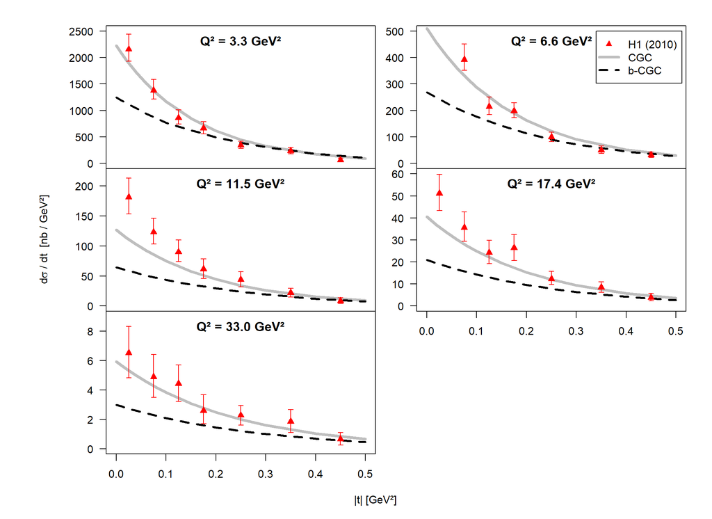

## Cross Section vs Q²

```r
par(mai = c(1.05, 1.05, 0.45, 0.40))
plot(0, 1, pch = 21, col = "white", bg = "white", xlim = c(1, 100), ylim = c(0.01, 1000), xlab = "Q² [GeV²]", ylab = expression(sigma*" [nb]"), log = "y", axes = FALSE)

# Modify the plot features

box(bty = "o")
axis(1, at = c("0", "10", "20", "30", "40", "50", "60", "70", "80", "90", "100"))
axis(2, at = c("0.01", "0.1", "1", "10", "100", "1000"), labels = c("0.01", "0.1", "1", "10", "100", "1000"), las = 1)
legend(70.1, 1280, c("H1 (2010)", "ZEUS (2007)", "CGC", "b-CGC"), lty = c(0, 0, 1, 2), pch = c(17, 19, NA_integer_, NA_integer_), col = c("red", "blue", "grey", "black"), lwd = c(NA_integer_, NA_integer_, 4, 3), bg = "white")

# Add theoretical data

lines(CGC_Q2_rho, CGC_sigma_vs_Q2_rho, col = "grey", lty = 1, lwd = 4)
lines(bCGC_Q2_rho, bCGC_sigma_vs_Q2_rho, col = "black", lty = 2, lwd = 3)

# Add experimental data

points(H1_2010_rho_sigma$Q2, H1_2010_rho_sigma$sigma, pch = 24, col = "red", bg = "red")
points(ZEUS_2007_rho_sigma$Q2, ZEUS_2007_rho_sigma$sigma, pch = 21, col = "blue", bg = "blue")

# Add error bars

arrows(H1_2010_rho_sigma$Q2, H1_2010_rho_sigma$pos_error, H1_2010_rho_sigma$Q2, H1_2010_rho_sigma$neg_error, length = 0.04, angle = 90, code = 3, col = "red")
arrows(ZEUS_2007_rho_sigma$Q2, ZEUS_2007_rho_sigma$pos_error, ZEUS_2007_rho_sigma$Q2, ZEUS_2007_rho_sigma$neg_error, length = 0.04, angle = 90, code = 3, col = "blue")

# Print the data frames

CGC_vs_Q2_rho

bCGC_vs_Q2_rho
```

## Cross Section vs W

```r
par(mfrow = c(3, 2), oma = c(5, 5, 2, 2), mar = c(0, 3.2, 0, 0), cex = 1, las = 1)

# Q2 = 0

plot(0, 0, ann = FALSE, xaxt = "n", yaxt = "n", xlim = c(40, 195), ylim = c(1000, 20000))
axis(2, at = c(5000, 10000, 15000, 20000))
title("Q² = 0 GeV²", line = -10, adj = 0.9)
lines(CGC_W_rho, CGC_vs_W_0_rho$sigma, lwd = 4, col = "grey")
lines(bCGC_W_rho, bCGC_vs_W_0_rho$sigma, lwd = 3, col = "black", lty = 2)
points(71.7, 11200, pch = 21, col = "blue", bg = "blue")
arrows(71.7, 12400, 71.7, 9900, length = 0.04, angle = 90, code = 3, col = "blue")

# Q2 = 3.3

plot(0, 0, ann = FALSE, xaxt = "n", yaxt = "n", xlim = c(40, 195), ylim = c(150, 650))
axis(2, at = c(200, 400, 600))
title("Q² = 3.3 GeV²", line = -10, adj = 0.9)
lines(CGC_W_rho, CGC_vs_W_3.3_rho$sigma, lwd = 4, col = "grey")
lines(bCGC_W_rho, bCGC_vs_W_3.3_rho$sigma, lwd = 3, col = "black", lty = 2)
points(H1_2010_rho_sigma_3.3$W, H1_2010_rho_sigma_3.3$sigma, pch = 24, col = "red", bg = "red")
arrows(H1_2010_rho_sigma_3.3$W, H1_2010_rho_sigma_3.3$pos_error, H1_2010_rho_sigma_3.3$W, H1_2010_rho_sigma_3.3$neg_error, length = 0.04, angle = 90, code = 3, col = "red")
legend(113, 650, c("H1 (2010)", "ZEUS (1998)", "CGC", "b-CGC"), lty = c(0, 0, 1, 2), lwd = c(NA_integer_, NA_integer_, 4, 3), pch = c(17, 19, NA_integer_, NA_integer_), col = c("red", "blue", "grey", "black"), bg = rgb(1, 1, 1, 0.8))

# Q2 = 6.6

plot(0, 0, ann = FALSE, xaxt = "n", yaxt = "n", xlim = c(40, 195), ylim = c(60, 140))
axis(2, at = c(80, 120))
title("Q² = 6.6 GeV²", line = -10, adj = 0.9)
lines(CGC_W_rho, CGC_vs_W_6.6_rho$sigma, lwd = 4, col = "grey")
lines(bCGC_W_rho, bCGC_vs_W_6.6_rho$sigma, lwd = 3, col = "black", lty = 2)
points(H1_2010_rho_sigma_6.6$W, H1_2010_rho_sigma_6.6$sigma, pch = 24, col = "red", bg = "red")
arrows(H1_2010_rho_sigma_6.6$W, H1_2010_rho_sigma_6.6$pos_error, H1_2010_rho_sigma_6.6$W, H1_2010_rho_sigma_6.6$neg_error, length = 0.04, angle = 90, code = 3, col = "red")

# Q2 = 11.9

plot(0, 0, ann = FALSE, xaxt = "n", yaxt = "n", xlim = c(40, 195), ylim = c(15, 45))
axis(2, at = c(20, 30, 40))
title("Q² = 11.9 GeV²", line = -10, adj = 0.9)
lines(CGC_W_rho, CGC_vs_W_11.9_rho$sigma, lwd = 4, col = "grey")
lines(bCGC_W_rho, bCGC_vs_W_11.9_rho$sigma, lwd = 3, col = "black", lty = 2)
points(H1_2010_rho_sigma_11.9$W, H1_2010_rho_sigma_11.9$sigma, pch = 24, col = "red", bg = "red")
arrows(H1_2010_rho_sigma_11.9$W, H1_2010_rho_sigma_11.9$pos_error, H1_2010_rho_sigma_11.9$W, H1_2010_rho_sigma_11.9$neg_error, length = 0.04, angle = 90, code = 3, col = "red")

# Q2 = 19.5

plot(0, 0, ann = FALSE, xaxt = "n", yaxt = "n", xlim = c(40, 195), ylim = c(0, 20))
axis(1, at = c(40, 80, 120, 160, 200))
axis(2, at = c(6, 12, 18))
title("Q² = 19.5 GeV²", line = -10, adj = 0.9)
lines(CGC_W_rho, CGC_vs_W_19.5_rho$sigma, lwd = 4, col = "grey")
lines(bCGC_W_rho, bCGC_vs_W_19.5_rho$sigma, lwd = 3, col = "black", lty = 2)
points(H1_2010_rho_sigma_19.5$W, H1_2010_rho_sigma_19.5$sigma, pch = 24, col = "red", bg = "red")
arrows(H1_2010_rho_sigma_19.5$W, H1_2010_rho_sigma_19.5$pos_error, H1_2010_rho_sigma_19.5$W, H1_2010_rho_sigma_19.5$neg_error, length = 0.04, angle = 90, code = 3, col = "red")

# Q2 = 35.6

plot(0, 0, ann = FALSE, xaxt = "n", yaxt = "n", xlim = c(40, 195), ylim = c(0, 5))
axis(1, at = c(40, 80, 120, 160, 200))
axis(2, at = c(0, 2, 4))
title("Q² = 35.6 GeV²", line = -10, adj = 0.9)
lines(CGC_W_rho, CGC_vs_W_35.6_rho$sigma, lwd = 4, col = "grey")
lines(bCGC_W_rho, bCGC_vs_W_35.6_rho$sigma, lwd = 3, col = "black", lty = 2)
points(H1_2010_rho_sigma_35.6$W, H1_2010_rho_sigma_35.6$sigma, pch = 24, col = "red", bg = "red")
arrows(H1_2010_rho_sigma_35.6$W, H1_2010_rho_sigma_35.6$pos_error, H1_2010_rho_sigma_35.6$W, H1_2010_rho_sigma_35.6$neg_error, length = 0.04, angle = 90, code = 3, col = "red")

mtext("W [GeV]", 1, 3, outer = TRUE)
mtext(expression(sigma*" [nb]"), 2, 1, outer = TRUE, las = 0)

# Print the data frames

CGC_vs_W_0_rho
CGC_vs_W_3.3_rho
CGC_vs_W_6.6_rho
CGC_vs_W_11.9_rho
CGC_vs_W_19.5_rho
CGC_vs_W_35.6_rho

bCGC_vs_W_0_rho
bCGC_vs_W_3.3_rho
bCGC_vs_W_6.6_rho
bCGC_vs_W_11.9_rho
bCGC_vs_W_19.5_rho
bCGC_vs_W_35.6_rho
```

```r
par(mfrow = c(3, 2), oma = c(5, 5, 2, 2), mar = c(0, 3.2, 0, 0), cex = 1, las = 1)

# Q2 = 2.4

plot(0, 0, ann = FALSE, xaxt = "n", yaxt = "n", xlim = c(35, 175), ylim = c(400, 1000))
axis(2, at = c(400, 600, 800, 1000))
title("Q² = 2.4 GeV²", line = -10, adj = 0.9)
lines(CGC_W_rho, CGC_vs_W_2.4_rho$sigma, lwd = 4, col = "grey")
lines(bCGC_W_rho, bCGC_vs_W_2.4_rho$sigma, lwd = 3, col = "black", lty = 2)
points(ZEUS_2007_rho_sigma_2.4$W, ZEUS_2007_rho_sigma_2.4$sigma, pch = 21, col = "blue", bg = "blue")
arrows(ZEUS_2007_rho_sigma_2.4$W, ZEUS_2007_rho_sigma_2.4$pos_error, ZEUS_2007_rho_sigma_2.4$W, ZEUS_2007_rho_sigma_2.4$neg_error, length = 0.04, angle = 90, code = 3, col = "blue")

# Q2 = 3.7

plot(0, 0, ann = FALSE, xaxt = "n", yaxt = "n", xlim = c(35, 175), ylim = c(200, 500))
axis(2, at = c(200, 300, 400, 500))
title("Q² = 3.7 GeV²", line = -10, adj = 0.9)
lines(CGC_W_rho, CGC_vs_W_3.7_rho$sigma, lwd = 4, col = "grey")
lines(bCGC_W_rho, bCGC_vs_W_3.7_rho$sigma, lwd = 3, col = "black", lty = 2)
points(ZEUS_2007_rho_sigma_3.7$W, ZEUS_2007_rho_sigma_3.7$sigma, pch = 21, col = "blue", bg = "blue")
arrows(ZEUS_2007_rho_sigma_3.7$W, ZEUS_2007_rho_sigma_3.7$pos_error, ZEUS_2007_rho_sigma_3.7$W, ZEUS_2007_rho_sigma_3.7$neg_error, length = 0.04, angle = 90, code = 3, col = "blue")
legend(100, 500, c("ZEUS (2007)", "CGC", "b-CGC"), lty = c(0, 1, 2), lwd = c(NA_integer_, 4, 3), pch = c(19, NA_integer_, NA_integer_), col = c("blue", "grey", "black"), bg = rgb(1, 1, 1, 0.8))

# Q2 = 6.0

plot(0, 0, ann = FALSE, xaxt = "n", yaxt = "n", xlim = c(35, 175), ylim = c(75, 175))
axis(2, at = c(100, 150))
title("Q² = 6.0 GeV²", line = -10, adj = 0.9)
lines(CGC_W_rho, CGC_vs_W_6.0_rho$sigma, lwd = 4, col = "grey")
lines(bCGC_W_rho, bCGC_vs_W_6.0_rho$sigma, lwd = 3, col = "black", lty = 2)
points(ZEUS_2007_rho_sigma_6.0$W, ZEUS_2007_rho_sigma_6.0$sigma, pch = 21, col = "blue", bg = "blue")
arrows(ZEUS_2007_rho_sigma_6.0$W, ZEUS_2007_rho_sigma_6.0$pos_error, ZEUS_2007_rho_sigma_6.0$W, ZEUS_2007_rho_sigma_6.0$neg_error, length = 0.04, angle = 90, code = 3, col = "blue")

# Q2 = 8.3

plot(0, 0, ann = FALSE, xaxt = "n", yaxt = "n", xlim = c(35, 175), ylim = c(40, 120))
axis(2, at = c(40, 80, 120))
title("Q² = 8.3 GeV²", line = -10, adj = 0.9)
lines(CGC_W_rho, CGC_vs_W_8.3_rho$sigma, lwd = 4, col = "grey")
lines(bCGC_W_rho, bCGC_vs_W_8.3_rho$sigma, lwd = 3, col = "black", lty = 2)
points(ZEUS_2007_rho_sigma_8.3$W, ZEUS_2007_rho_sigma_8.3$sigma, pch = 21, col = "blue", bg = "blue")
arrows(ZEUS_2007_rho_sigma_8.3$W, ZEUS_2007_rho_sigma_8.3$pos_error, ZEUS_2007_rho_sigma_8.3$W, ZEUS_2007_rho_sigma_8.3$neg_error, length = 0.04, angle = 90, code = 3, col = "blue")

# Q2 = 13.5

plot(0, 0, ann = FALSE, xaxt = "n", yaxt = "n", xlim = c(35, 175), ylim = c(10, 50))
axis(1, at = c(40, 80, 120, 160))
axis(2, at = c(10, 20, 30, 40, 50))
title("Q² = 13.5 GeV²", line = -10, adj = 0.9)
lines(CGC_W_rho, CGC_vs_W_13.5_rho$sigma, lwd = 4, col = "grey")
lines(bCGC_W_rho, bCGC_vs_W_13.5_rho$sigma, lwd = 3, col = "black", lty = 2)
points(ZEUS_2007_rho_sigma_13.5$W, ZEUS_2007_rho_sigma_13.5$sigma, pch = 21, col = "blue", bg = "blue")
arrows(ZEUS_2007_rho_sigma_13.5$W, ZEUS_2007_rho_sigma_13.5$pos_error, ZEUS_2007_rho_sigma_13.5$W, ZEUS_2007_rho_sigma_13.5$neg_error, length = 0.04, angle = 90, code = 3, col = "blue")

# Q2 = 32.0

plot(0, 0, ann = FALSE, xaxt = "n", yaxt = "n", xlim = c(35, 175), ylim = c(0, 5))
axis(1, at = c(40, 80, 120, 160))
axis(2, at = c(0, 2, 4))
title("Q² = 32.0 GeV²", line = -10, adj = 0.9)
lines(CGC_W_rho, CGC_vs_W_32.0_rho$sigma, lwd = 4, col = "grey")
lines(bCGC_W_rho, bCGC_vs_W_32.0_rho$sigma, lwd = 3, col = "black", lty = 2)
points(ZEUS_2007_rho_sigma_32.0$W, ZEUS_2007_rho_sigma_32.0$sigma, pch = 21, col = "blue", bg = "blue")
arrows(ZEUS_2007_rho_sigma_32.0$W, ZEUS_2007_rho_sigma_32.0$pos_error, ZEUS_2007_rho_sigma_32.0$W, ZEUS_2007_rho_sigma_32.0$neg_error, length = 0.04, angle = 90, code = 3, col = "blue")

mtext("W [GeV]", 1, 3, outer = TRUE)
mtext(expression(sigma*" [nb]"), 2, 1, outer = TRUE, las = 0)

# Print the data frames

CGC_vs_W_2.4_rho
CGC_vs_W_3.7_rho
CGC_vs_W_6.0_rho
CGC_vs_W_8.3_rho
CGC_vs_W_13.5_rho
CGC_vs_W_32.0_rho

bCGC_vs_W_2.4_rho
bCGC_vs_W_3.7_rho
bCGC_vs_W_6.0_rho
bCGC_vs_W_8.3_rho
bCGC_vs_W_13.5_rho
bCGC_vs_W_32.0_rho
```

## Ratio vs Q²

```r
par(mai = c(1.05, 1.05, 0.45, 0.40))
plot(0, 1, pch = 21, col = "white", bg = "white", xlim = c(1, 50), ylim = c(0.5, 11), xlab = "Q² [GeV²]", ylab = expression(sigma["L"]*" / "*sigma["T"]*""), axes = FALSE)

# Modify the plot features

box(bty = "o")
axis(1, at = c("0", "5", "10", "15", "20", "25", "30", "35", "40", "45", "50"))
axis(2, at = c("0", "1", "2", "3", "4", "5", "6", "7", "8", "9", "10", "11"), las = 1)
legend(1, 11, c("H1 (2000)", "H1 (2010)", "ZEUS (2007)", "CGC", "b-CGC"), lty = c(0, 0, 0, 1, 2), pch = c(15, 17, 19, NA_integer_, NA_integer_), col = c("green", "red", "blue", "grey", "black"), lwd = c(NA_integer_, NA_integer_, NA_integer_, 4, 3), bg = "white")

# Add theoretical data

lines(CGC_Q2_rho, CGC_ratio_vs_Q2_rho, col = "grey", lty = 1, lwd = 4)
lines(bCGC_Q2_rho, bCGC_ratio_vs_Q2_rho, col = "black", lty = 2, lwd = 3)

# Add experimental data

points(H1_2000_rho_ratio$Q2, H1_2000_rho_ratio$ratio, pch = 22, col = "green", bg = "green")
points(H1_2010_rho_ratio$Q2, H1_2010_rho_ratio$ratio, pch = 24, col = "red", bg = "red")
points(ZEUS_2007_rho_ratio$Q2, ZEUS_2007_rho_ratio$ratio, pch = 21, col = "blue", bg = "blue")

# Add error bars

arrows(H1_2000_rho_ratio$Q2, H1_2000_rho_ratio$pos_error, H1_2000_rho_ratio$Q2, H1_2000_rho_ratio$neg_error, length = 0.04, angle = 90, code = 3, col = "green")
arrows(H1_2010_rho_ratio$Q2, H1_2010_rho_ratio$pos_error, H1_2010_rho_ratio$Q2, H1_2010_rho_ratio$neg_error, length = 0.04, angle = 90, code = 3, col = "red")
arrows(ZEUS_2007_rho_ratio$Q2, ZEUS_2007_rho_ratio$pos_error, ZEUS_2007_rho_ratio$Q2, ZEUS_2007_rho_ratio$neg_error, length = 0.04, angle = 90, code = 3, col = "blue")

# Print the data frames

CGC_vs_Q2_rho

bCGC_vs_Q2_rho
```

# Phi Plots

## Differential Cross Section vs |t|

```r
par(mfrow = c(3, 1), oma = c(5, 5, 2, 2), mar = c(0, 3.2, 0, 0), cex = 1, las = 1)

# Q2 = 3.3

plot(0, 1, ann = FALSE, xaxt = "n", log = "y", xlim = c(0, 0.5), ylim = c(10, 500), col = "white")
title("Q² = 3.3 GeV²", line = -1.5)
lines(CGC_t_phi, CGC_d_sigma_3.3_phi$d_sigma, lwd = 4, col = "grey")
lines(bCGC_t_phi, bCGC_d_sigma_3.3_phi$d_sigma, lwd = 3, col = "black", lty = 2)
points(H1_2010_phi_d_sigma_3.3$t, H1_2010_phi_d_sigma_3.3$d_sigma, pch = 24, col = "red", bg = "red")
arrows(H1_2010_phi_d_sigma_3.3$t, H1_2010_phi_d_sigma_3.3$pos_error, H1_2010_phi_d_sigma_3.3$t, H1_2010_phi_d_sigma_3.3$neg_error, length = 0.04, angle = 90, code = 3, col = "red")
legend(0.355, 500, c("H1 (2010)", "CGC", "b-CGC"), lty = c(0, 1, 2), lwd = c(NA_integer_, 4, 3), pch = c(17, NA_integer_, NA_integer_), col = c("red", "grey", "black"))

# Q2 = 6.6

plot(0, 1, ann = FALSE, xaxt = "n", log = "y", xlim = c(0, 0.5), ylim = c(3, 110), col = "white")
title("Q² = 6.6 GeV²", line = -1.5)
lines(CGC_t_phi, CGC_d_sigma_6.6_phi$d_sigma, lwd = 4, col = "grey")
lines(bCGC_t_phi, bCGC_d_sigma_6.6_phi$d_sigma, lwd = 3, col = "black", lty = 2)
points(H1_2010_phi_d_sigma_6.6$t, H1_2010_phi_d_sigma_6.6$d_sigma, pch = 24, col = "red", bg = "red")
arrows(H1_2010_phi_d_sigma_6.6$t, H1_2010_phi_d_sigma_6.6$pos_error, H1_2010_phi_d_sigma_6.6$t, H1_2010_phi_d_sigma_6.6$neg_error, length = 0.04, angle = 90, code = 3, col = "red")

# Q2 = 15.8

plot(0, 1, ann = FALSE, log = "y", xlim = c(0, 0.5), ylim = c(0.1, 50), col = "white")
title("Q² = 15.8 GeV²", line = -1.5)
lines(CGC_t_phi, CGC_d_sigma_15.8_phi$d_sigma, lwd = 4, col = "grey")
lines(bCGC_t_phi, bCGC_d_sigma_15.8_phi$d_sigma, lwd = 3, col = "black", lty = 2)
points(H1_2010_phi_d_sigma_15.8$t, H1_2010_phi_d_sigma_15.8$d_sigma, pch = 24, col = "red", bg = "red")
arrows(H1_2010_phi_d_sigma_15.8$t, H1_2010_phi_d_sigma_15.8$pos_error, H1_2010_phi_d_sigma_15.8$t, H1_2010_phi_d_sigma_15.8$neg_error, length = 0.04, angle = 90, code = 3, col = "red")

mtext("|t| [GeV²]", 1, 3, outer = TRUE)
mtext(expression("d"*sigma*" / dt  [nb / GeV²]"), 2, 1, outer = TRUE, las = 0)

# Print the data frames

CGC_d_sigma_3.3_phi
CGC_d_sigma_6.6_phi
CGC_d_sigma_15.8_phi

bCGC_d_sigma_3.3_phi
bCGC_d_sigma_6.6_phi
bCGC_d_sigma_15.8_phi
```

## Cross Section vs Q²

```r
par(mai = c(1.05, 1.05, 0.45, 0.40))
plot(0, 0, pch = 21, col = "white", bg = "white", xlim = c(1, 50), ylim = c(0.05, 110), xlab = "Q² [GeV²]", ylab = expression(sigma*" [nb]"), log = "y", axes = FALSE)

# Modify the plot features

box(bty = "o")
axis(1, at = c("0", "10", "20", "30", "40", "50", "60", "70", "80", "90", "100"))
axis(2, at = c("0.01", "0.1", "1", "10", "100", "1000"), labels = c("0.01", "0.1", "1", "10", "100", "1000"), las = 1)
legend(35.2, 133, c("H1 (2010)", "ZEUS (2005)", "CGC", "b-CGC"), lty = c(0, 0, 1, 2), pch = c(17, 19, NA_integer_, NA_integer_), col = c("red", "blue", "grey", "black"), lwd = c(NA_integer_, NA_integer_, 4, 3), bg = "white")

# Add theoretical data

lines(CGC_Q2_phi, CGC_sigma_vs_Q2_phi$sigma, col = "grey", lty = 1, lwd = 4)
lines(bCGC_Q2_phi, bCGC_sigma_vs_Q2_phi$sigma, col = "black", lty = 2, lwd = 3)

# Add experimental data

points(H1_2010_phi_sigma$Q2, H1_2010_phi_sigma$sigma, pch = 24, col = "red", bg = "red")
points(ZEUS_2005_phi_sigma$Q2, ZEUS_2005_phi_sigma$sigma, pch = 21, col = "blue", bg = "blue")

# Add error bars

arrows(H1_2010_phi_sigma$Q2, H1_2010_phi_sigma$pos_error, H1_2010_phi_sigma$Q2, H1_2010_phi_sigma$neg_error, length = 0.04, angle = 90, code = 3, col = "red")
arrows(ZEUS_2005_phi_sigma$Q2, ZEUS_2005_phi_sigma$pos_error, ZEUS_2005_phi_sigma$Q2, ZEUS_2005_phi_sigma$neg_error, length = 0.04, angle = 90, code = 3, col = "blue")

# Print the data frames

CGC_sigma_vs_Q2_phi

bCGC_sigma_vs_Q2_phi
```

## Cross Section vs W

```r
par(mfrow = c(2, 2), oma = c(5, 5, 2, 2), mar = c(0, 3.2, 0, 0), cex = 1, las = 1)

# Q2 = 2.4

plot(0, 0, ann = FALSE, xaxt = "n", yaxt = "n", xlim = c(35, 140), ylim = c(40, 180))
axis(2, at = c(40, 60, 80, 100, 120, 140, 160, 180))
title("Q² = 2.4 GeV²", line = -10, adj = 0.9)
lines(CGC_W_phi, CGC_vs_W_2.4_phi$sigma, lwd = 4, col = "grey")
lines(bCGC_W_phi, bCGC_vs_W_2.4_phi$sigma, lwd = 3, col = "black", lty = 2)
points(ZEUS_2005_phi_sigma_2.4$W, ZEUS_2005_phi_sigma_2.4$sigma, pch = 21, col = "blue", bg = "blue")
arrows(ZEUS_2005_phi_sigma_2.4$W, ZEUS_2005_phi_sigma_2.4$pos_error, ZEUS_2005_phi_sigma_2.4$W, ZEUS_2005_phi_sigma_2.4$neg_error, length = 0.04, angle = 90, code = 3, col = "blue")

# Q2 = 3.8

plot(0, 0, ann = FALSE, xaxt = "n", yaxt = "n", xlim = c(35, 140), ylim = c(20, 80))
axis(2, at = c(20, 40, 60, 80))
title("Q² = 3.8 GeV²", line = -10, adj = 0.9)
lines(CGC_W_phi, CGC_vs_W_3.8_phi$sigma, lwd = 4, col = "grey")
lines(bCGC_W_phi, bCGC_vs_W_3.8_phi$sigma, lwd = 3, col = "black", lty = 2)
points(ZEUS_2005_phi_sigma_3.8$W, ZEUS_2005_phi_sigma_3.8$sigma, pch = 21, col = "blue", bg = "blue")
arrows(ZEUS_2005_phi_sigma_3.8$W, ZEUS_2005_phi_sigma_3.8$pos_error, ZEUS_2005_phi_sigma_3.8$W, ZEUS_2005_phi_sigma_3.8$neg_error, length = 0.04, angle = 90, code = 3, col = "blue")
legend(84, 80, c("ZEUS (2005)", "CGC", "b-CGC"), lty = c(0, 1, 2), lwd = c(NA_integer_, 4, 3), pch = c(19, NA_integer_, NA_integer_), col = c("blue", "grey", "black"), bg = rgb(1, 1, 1, 0.8))

# Q2 = 6.5

plot(0, 0, ann = FALSE, xaxt = "n", yaxt = "n", xlim = c(35, 140), ylim = c(5, 35))
axis(1, at = c(40, 60, 80, 100, 120, 140))
axis(2, at = c(5, 10, 15, 20, 25, 30, 35))
title("Q² = 6.5 GeV²", line = -10, adj = 0.9)
lines(CGC_W_phi, CGC_vs_W_6.5_phi$sigma, lwd = 4, col = "grey")
lines(bCGC_W_phi, bCGC_vs_W_6.5_phi$sigma, lwd = 3, col = "black", lty = 2)
points(ZEUS_2005_phi_sigma_6.5$W, ZEUS_2005_phi_sigma_6.5$sigma, pch = 21, col = "blue", bg = "blue")
arrows(ZEUS_2005_phi_sigma_6.5$W, ZEUS_2005_phi_sigma_6.5$pos_error, ZEUS_2005_phi_sigma_6.5$W, ZEUS_2005_phi_sigma_6.5$neg_error, length = 0.04, angle = 90, code = 3, col = "blue")

# Q2 = 13.0

plot(0, 0, ann = FALSE, xaxt = "n", yaxt = "n", xlim = c(35, 140), ylim = c(4, 8))
axis(1, at = c(40, 60, 80, 100, 120, 140))
axis(2, at = c(4, 5, 6, 7, 8))
title("Q² = 13.0 GeV²", line = -10, adj = 0.9)
lines(CGC_W_phi, CGC_vs_W_13.0_phi$sigma, lwd = 4, col = "grey")
lines(bCGC_W_phi, bCGC_vs_W_13.0_phi$sigma, lwd = 3, col = "black", lty = 2)
points(ZEUS_2005_phi_sigma_13.0$W, ZEUS_2005_phi_sigma_13.0$sigma, pch = 21, col = "blue", bg = "blue")
arrows(ZEUS_2005_phi_sigma_13.0$W, ZEUS_2005_phi_sigma_13.0$pos_error, ZEUS_2005_phi_sigma_13.0$W, ZEUS_2005_phi_sigma_13.0$neg_error, length = 0.04, angle = 90, code = 3, col = "blue")

mtext("W [GeV]", 1, 3, outer = TRUE)
mtext(expression(sigma*" [nb]"), 2, 1, outer = TRUE, las = 0)

# Print the data frames

CGC_vs_W_2.4_phi
CGC_vs_W_3.8_phi
CGC_vs_W_6.5_phi
CGC_vs_W_13.0_phi

bCGC_vs_W_2.4_phi
bCGC_vs_W_3.8_phi
bCGC_vs_W_6.5_phi
bCGC_vs_W_13.0_phi
```

```r
par(mfrow = c(3, 1), oma = c(5, 5, 2, 2), mar = c(0, 3.2, 0, 0), cex = 1, las = 1)

# Q2 = 3.3

plot(0, 0, ann = FALSE, xaxt = "n", yaxt = "n", xlim = c(40, 170), ylim = c(20, 100))
axis(2, at = c(20, 40, 60, 80, 100))
title("Q² = 3.3 GeV²", line = -10, adj = 0.9)
lines(CGC_W_phi, CGC_vs_W_3.3_phi$sigma, lwd = 4, col = "grey")
lines(bCGC_W_phi, bCGC_vs_W_3.3_phi$sigma, lwd = 3, col = "black", lty = 2)
points(H1_2010_phi_sigma_3.3$W, H1_2010_phi_sigma_3.3$sigma, pch = 24, col = "red", bg = "red")
arrows(H1_2010_phi_sigma_3.3$W, H1_2010_phi_sigma_3.3$pos_error, H1_2010_phi_sigma_3.3$W, H1_2010_phi_sigma_3.3$neg_error, length = 0.04, angle = 90, code = 3, col = "red")
legend(132, 100, c("H1 (2010)", "CGC", "b-CGC"), lty = c(0, 1, 2), lwd = c(NA_integer_, 4, 3), pch = c(17, NA_integer_, NA_integer_), col = c("red", "grey", "black"), bg = rgb(1, 1, 1, 0.8))

# Q2 = 6.6

plot(0, 0, ann = FALSE, xaxt = "n", yaxt = "n", xlim = c(40, 170), ylim = c(5, 30))
axis(2, at = c(5, 10, 15, 20, 25, 30))
title("Q² = 6.6 GeV²", line = -10, adj = 0.9)
lines(CGC_W_phi, CGC_vs_W_6.6_phi$sigma, lwd = 4, col = "grey")
lines(bCGC_W_phi, bCGC_vs_W_6.6_phi$sigma, lwd = 3, col = "black", lty = 2)
points(H1_2010_phi_sigma_6.6$W, H1_2010_phi_sigma_6.6$sigma, pch = 24, col = "red", bg = "red")
arrows(H1_2010_phi_sigma_6.6$W, H1_2010_phi_sigma_6.6$pos_error, H1_2010_phi_sigma_6.6$W, H1_2010_phi_sigma_6.6$neg_error, length = 0.04, angle = 90, code = 3, col = "red")

# Q2 = 15.8

plot(0, 0, ann = FALSE, xaxt = "n", yaxt = "n", xlim = c(40, 170), ylim = c(1, 12))
axis(1, at = c(40, 60, 80, 100, 120, 140, 160))
axis(2, at = c(2, 4, 6, 8, 10, 12))
title("Q² = 15.8 GeV²", line = -10, adj = 0.9)
lines(CGC_W_phi, CGC_vs_W_15.8_phi$sigma, lwd = 4, col = "grey")
lines(bCGC_W_phi, bCGC_vs_W_15.8_phi$sigma, lwd = 3, col = "black", lty = 2)
points(H1_2010_phi_sigma_15.8$W, H1_2010_phi_sigma_15.8$sigma, pch = 24, col = "red", bg = "red")
arrows(H1_2010_phi_sigma_15.8$W, H1_2010_phi_sigma_15.8$pos_error, H1_2010_phi_sigma_15.8$W, H1_2010_phi_sigma_15.8$neg_error, length = 0.04, angle = 90, code = 3, col = "red")

mtext("W [GeV]", 1, 3, outer = TRUE)
mtext(expression(sigma*" [nb]"), 2, 1, outer = TRUE, las = 0)

# Print the data frames

CGC_vs_W_3.3_phi
CGC_vs_W_6.6_phi
CGC_vs_W_15.8_phi

bCGC_vs_W_3.3_phi
bCGC_vs_W_6.6_phi
bCGC_vs_W_15.8_phi
```

## Ratio vs Q²

```r
par(mai = c(1.05, 1.05, 0.45, 0.40))
plot(0, 1, pch = 21, col = "white", bg = "white", xlim = c(1, 25), ylim = c(0.5, 11), xlab = "Q² [GeV²]", ylab = expression(sigma["L"]*" / "*sigma["T"]*""), axes = FALSE)

# Modify the plot features

box(bty = "o")
axis(1, at = c("0", "5", "10", "15", "20", "25", "30", "35", "40", "45", "50"))
axis(2, at = c("0", "1", "2", "3", "4", "5", "6", "7", "8", "9", "10", "11"), las = 1)
legend(1, 11, c("H1 (2010)", "ZEUS (2005)", "CGC", "b-CGC"), lty = c(0, 0, 1, 2), pch = c(17, 19, NA_integer_, NA_integer_), col = c("red", "blue", "grey", "black"), lwd = c(NA_integer_, NA_integer_, 4, 3), bg = "white")

# Add theoretical data

lines(CGC_Q2_phi, CGC_ratio_vs_Q2_phi$ratio, col = "grey", lty = 1, lwd = 4)
lines(bCGC_Q2_phi, bCGC_ratio_vs_Q2_phi$ratio, col = "black", lty = 2, lwd = 3)

# Add experimental data

points(H1_2010_phi_ratio$Q2, H1_2010_phi_ratio$ratio, pch = 24, col = "red", bg = "red")
points(ZEUS_2005_phi_ratio$Q2, ZEUS_2005_phi_ratio$ratio, pch = 21, col = "blue", bg = "blue")

# Add error bars

arrows(H1_2010_phi_ratio$Q2, H1_2010_phi_ratio$pos_error, H1_2010_phi_ratio$Q2, H1_2010_phi_ratio$neg_error, length = 0.04, angle = 90, code = 3, col = "red")
arrows(ZEUS_2005_phi_ratio$Q2, ZEUS_2005_phi_ratio$pos_error, ZEUS_2005_phi_ratio$Q2, ZEUS_2005_phi_ratio$neg_error, length = 0.04, angle = 90, code = 3, col = "blue")

# Print the data frames

CGC_ratio_vs_Q2_phi

bCGC_ratio_vs_Q2_phi
```

# Chi-Square Function

This function makes use of the structure of the data frames that hold the H1 and ZEUS data:

| Data[,1] | Data[,2] | Data[,3] | Data[,4] |
| --- | --- | --- | --- |
| `$W`, `$Q2`, or `$t` | `$d_sigma`, `$sigma`, or `$ratio` | `$pos_err` | `$neg_err` |

```r
chi_square = function (Data, Q2, W, meson) {

  # Create an empty vector to hold the summand values

  value = vector(mode = "double", length = length(Data))

  # Loop over all data points i

  for (i in seq_along(Data[, 1])) {

    # Print the i value to track progress

    print(i)

    # Determine whether the chi-square is for plots against Q2 or W
    # Then select the corresponding Q2 or W value for the data point i

    if (length(Q2) - 1 > 0) {

      Q2_value = Q2[i]
      W_value = W[i]

    } else {

      Q2_value = Q2[i]
      W_value = W[i]

    }

    # Calculate expected values using the bCGC() function
    # Then obtain errors from the data
    # Data[,3] and Data[,4] are sums of sigma + statistical error + systematic error, so "- experimental" is needed

    experimental = Data[i, 2]
    theoretical = bCGC(Q2_value, W_value, meson, return = "sigma")$sigma
    error = ifelse(theoretical - experimental > 0, Data[i, 3] - experimental, Data[i, 4] - experimental)

    value[i] = ((theoretical - experimental)/error)**2

  }

  # Sum over all data points, and divide by the number of degrees of freedom
  # Subtract 4 (not 5) to calculate the degrees of freedom, because B_CGC is fixed, not, free, in Reference [2]
  # Return the reduced chi-square

  sum(value)/(length(Data[, 1]) - 4)

}
```